# A Robust Machine Learning Framework for Outcome-wide Exposome Data Analysis

A Comprehensive msRRR Hands-On Tutorial

Augusto Anguita-Ruiz — Original methodology and implementation | María Arteaga Jover — Updates, robustness and workflow maintenance

August 07, 2026

# 1. INTRODUCTION: The High-Dimensional Challenge

## 1.1 The Curse of Dimensionality: From Univariate to Outcome-Wide Analysis

The concept of the “exposome” encompasses all environmental exposures to which an individual is subjected from conception onward (Wild 2005). An increasing number of studies have evidenced the fundamental role of the early-life exposome in the development of the most common non-communicable diseases, pointing to the prenatal and early childhood periods as critical windows of opportunity for disease prevention (Agier et al. 2019; Maitre et al. 2021; Vrijheid et al. 2020).

Traditionally, exposome research has focused on studying different health outcomes separately, under what is known as the single-outcome approach (Barrera-Gómez et al. 2017; Vrijheid et al. 2020). Although this analysis is valid, it often fails to provide a comprehensive vision, especially when exposures are presumed to have multiple, interconnected effects on health. To overcome this, advanced methods for *outcome-wide* analysis have been developed, where the effect of an environmental exposure on multiple health outcomes is investigated simultaneously (VanderWeele 2017; VanderWeele et al. 2020).

**The Power of the Outcome-Wide Exposome Approach**

Outcome-wide studies offer critical benefits in exposome research. Environmental exposures rarely affect a single biological system; instead, they influence multiple health outcomes that usually manifest in populations as complex comorbidities (e.g., cardiometabolic alterations co-occurring with respiratory problems and neurodevelopmental delays).

Methodologically, an outcome-wide analysis directly models the correlations among these multiple exposures and diverse outcomes. This allows the model to “borrow information” across different exposure-outcome pairs. Consequently, it significantly increases the statistical power to detect subtle, yet highly relevant, signals that would not be strong enough to reach significance in a traditional, isolated single-outcome analysis (Kundu et al. 2021). Furthermore, this holistic perspective can uncover ambiguous or pleiotropic risk factors—exposures that might be beneficial for one biological system but harmful to another—while inherently preventing the selective reporting of results and avoiding the massive statistical penalties associated with multiple testing. From a public health perspective, identifying these “master” environmental drivers that simultaneously impact multiple disease pathways is invaluable for designing high-impact preventive interventions.

**The Analytical Challenge and the msRRR Solution**

Despite its theoretical advantages, outcome-wide exposome research poses severe statistical challenges: the massive increase in dimensionality (the classic $P \gg N$ problem), the extreme collinearity among environmental variables, the exponential risk of false positives, and the need to integrate mixed-type responses. While most previous studies have relied on classical multivariate regressions that barely improve efficiency, the most advanced solutions stem from the omics fields, designed to identify “master regulators”.

To robustly address these challenges, this pipeline implements the **msRRR (Mixed-Response Sparse Reduced-Rank Regression)** framework. The model minimizes:
$$-\log L(Y,
X, Z) + \lambda ||U||_{2,1} \quad \text{s.t.} \quad V^T V =
I_r$$

Where: - **-log L**: Likelihood fit (Gaussian for continuous, Binomial for binary) - **λ||U||₂,₁**: Group-Lasso penalty shrinking weak exposures - **Rank constraint**: Data flows through r latent factors (B = UV^T)

This statistical engine is specifically tailored for the exposome’s complexities:

1. **Simultaneous Mixed Responses:** It allows integrating outcomes of different statistical natures into a single mathematical architecture (e.g., continuous variables like BMI z-score alongside binary variables like Asthma diagnosis).
2. **Dimensionality Reduction (Rank $r$):** It assumes that exposures affect health outcomes through latent factors or “shared biological pathways,” leveraging the comorbidity structure to radically simplify the model.
3. **Strict Sparsity (Group-Lasso):** It applies a mathematical penalty ($\lambda$) that forces the coefficients of irrelevant exposures to exactly zero, acting as a rigorous noise filter that neutralizes the false-positive explosion typical of high-dimensional environments.
4. **Validation Architecture**: Strict train/test separation prevents data leakage
5. **Stability Selection**: N-iteration balanced bootstrap to distinguish true drivers from noise

# 2. SETUP: Environment Configuration & Library Loading

## 2.1 Theoretical Motivation for Setup

This prevents silent errors and allows the pipeline to scale to large datasets.

```r
# BLOCK 1: SET UP & LIBRARIES
# ------------------------------------------------------------------------------

# Clean environment
rm(list = ls())

# Optional lightweight end-to-end validation. Normal runs leave this variable
# unset. Set MSRRR_SMOKE_TEST=true before rendering to use a temporary output
# directory, a small tuning grid and two bootstrap resamples, with LOCO skipped.
smoke_test <- identical(
  tolower(Sys.getenv("MSRRR_SMOKE_TEST", unset = "false")), "true"
)

# Create the common output directory before any plot, checkpoint or table is
# written. recursive = TRUE is harmless when the directory already exists.
results_dir <- if (smoke_test) {
  file.path(tempdir(), "msrrr_rmarkdown_smoke_results")
} else {
  "results"
}
dir.create(results_dir, recursive = TRUE, showWarnings = FALSE)
if (!dir.exists(results_dir)) {
  stop("The output directory could not be created: ", results_dir)
}

# ------------------------------------------------------------------------------
# MODEL SELECTION AND BOOTSTRAP SETTINGS
# ------------------------------------------------------------------------------

# Number of lambda values evaluated along the penalisation path.
# Around 50 values usually provide sufficient resolution for model selection.
# Increase this value if the CV curve changes sharply near its minimum or if
# finer discrimination between neighbouring lambda values is required. This
# tutorial uses 25 because to substantially reduce computation time.
n_lambda <- if (smoke_test) 2L else 25L

# Candidate reduced ranks evaluated by cross-validation.
# Rank 1 should normally be included. The upper value should reflect the
# expected latent structure and cannot meaningfully exceed
# min(ncol(X), ncol(Y)). Review the rank-boundary diagnostics after fitting.
rank_sequence <- if (smoke_test) 1L else 1:4

# Number of bootstrap resamples used by both post-selection approaches.
# At least 500 resamples are recommended for a definitive analysis. This
# tutorial uses 100 because it demonstrates both bootstrap approaches and
# optional LOCO analyses, which substantially increases computation time.
n_boot_global <- if (smoke_test) 2L else 100L

if (smoke_test) {
  message(">>> MSRRR_SMOKE_TEST enabled: using reduced settings and temporary outputs.")
}

# Close all open graphical devices from previous/interrupted runs
graphics.off()
if (!is.null(dev.list())) {dev.off()}
```

```r
# Sanity check
print(dev.list())
```

```r
# Define all required packages
required_packages <- c(
  "tidyverse", "rrpack", "foreach", "doParallel", "pheatmap", "glmnet",
  "fastDummies", "gridExtra", "corrplot","caret","ggrepel","reshape2",
  "RColorBrewer", "grid", "doSNOW"
)

# Install missing packages
new_packages <- required_packages[!(required_packages %in% installed.packages()[,"Package"])]
if(length(new_packages)) install.packages(new_packages)

# Load libraries
suppressPackageStartupMessages({
  library(tidyverse)
  library(rrpack)
  library(foreach)
  library(doParallel)
  library(doSNOW)
  library(pheatmap)
  library(glmnet)
  library(fastDummies)
  library(gridExtra)
  library(corrplot)
  library(caret)
  library(ggrepel)
  library(reshape2)
  library(RColorBrewer)
  library(grid)
})

# SOURCE EXTERNAL FUNCTIONS
# Ensure these files are in a 'functions' subfolder
if(file.exists("functions/msrrr_v4.R")) {
  source("functions/msrrr_v4.R")
  source("functions/bootstrapping_functions_v_31_07_26.r")
  source("functions/msrrr_plotting_functions.R")
  source("functions/msrrr_tutorial_workflow_functions.R")
  selection_tol <- 1e-12
  message(">>> Setup Complete. Libraries and Functions loaded.")
} else {
  stop("ERROR: Functions not found. Please check your 'functions' folder.")
}


# ------------------------------------------------------------------------------
```

**Key Packages:** - `rrpack`: Implements reduced-rank regression core - `doParallel`: Parallelizes bootstrap iterations - `pheatmap`: Professional heatmap visualization - `tidyverse`: Data manipulation and ggplot2 graphics

# 3. DATA LOADING: Structure & Hierarchy

## 3.1 Why Data Structure Matters

Real epidemiological data requires:

1. **Multiple formats**: European CSV format (semicolons, comma decimals).
2. **Multiple matrices**:
   - **X** (Exposures): Hundreds of environmental factors.
   - **Y** (Outcomes): Mixed continuous & binary health measures.
   - **Z** (Covariates): Confounders (sex, age, cohort, education, maternal BMI, etc.)
3. **Codebook alignment**: Variable metadata for family grouping.

```r
# BLOCK 2: LOAD DATA
# ------------------------------------------------------------------------------

# Helper to read European CSVs (semicolon separated, comma decimals)
# Workflow helper functions used below are defined in
# functions/msrrr_tutorial_workflow_functions.R.

message(">>> Loading data files...")
covs_raw <- read_euro_csv("data/covariates.csv")
exp_raw  <- read_euro_csv("data/exposome.csv")
# Loading the version with NAs as requested (Standard CSV read)
phen_raw <- read.csv("data/phenotype_NA.csv", row.names = 1, na.strings = "NA")
# ------------------------------------------------------------------------------
```

# 4. VARIABLE SELECTION & PROCESSING: Strategic Filtering

## 4.1 The Variable Selection Rationale

For this practical tutorial, we will use data from the **HELIX exposome study**. The HELIX study is a collaborative project between six longitudinal, population-based birth cohort studies from six European countries (France, Greece, Lithuania, Norway, Spain and the UK).

**Note:** The data provided in this introductory course were semi-simulated from the real data of the HELIX sub-cohort. For more details on the HELIX project and the origin of the data collected we recommend consulting the following publication (https://bmjopen.bmj.com/content/8/9/e021311) and website (https://www.projecthelix.eu/es).

The **exposome data (n = 1301)** that we will use are contained in separated csv files:

1. `phenotype` (outcomes)
2. `exposome` (exposome)
3. `covariates` (covariates)

The `exposome` database contains more than **200 exposures**.The description of each variable (name, structure, variable type, transformation, etc.) is detailed in the codebook. **Here, we will use the codebook to pre-select exposures and outcomes for this tutorial**.

```r
# BLOCK 3: VARIABLE SELECTION & PROCESSING
# ------------------------------------------------------------------------------
message(">>> [Block 3] Starting Variable Selection with fastDummies...")

# 3.1 Load Codebook
codebook <- read_euro_csv("data/codebook.csv")

# A. Target Families (Numeric variables)
target_families <- c(
  "Air Pollution", "Built environment", "Indoor air", "Lifestyle",
  "Metals", "Meteorological", "Natural Spaces", "Organochlorines",
  "Per- and polyfluoroalkyl substances (PFAS)", "Social and economic capital",
  "Tobacco Smoke", "Traffic", "Water DBPs"
)

# B. Forced Factors (Variables to convert to Dummies)
forced_factors <- c(
  "e3_alcpreg_yn_None", "h_pamod_t3_None", "h_pavig_t3_None",
  "FAS_cat_None", "hs_globalexp2_None"
)

# 3.2 Filter Variables from Codebook
vars_info <- codebook %>%
  dplyr::filter(
    (family %in% target_families & var_type == "numeric") |
      (variable_name %in% forced_factors)
  )

# 3.3 Split Variables by Period
vars_preg_names  <- vars_info %>% dplyr::filter(period == "Pregnancy") %>% dplyr::pull(variable_name)
vars_child_names <- vars_info %>% dplyr::filter(period == "Postnatal") %>% dplyr::pull(variable_name)

# Intersect with available data (Safety check)
vars_preg_names  <- intersect(vars_preg_names, colnames(exp_raw))
vars_child_names <- intersect(vars_child_names, colnames(exp_raw))


# 3.4 Process Exposome Matrices (X)
# Workflow helper functions used below are defined in functions/msrrr_tutorial_workflow_functions.R.

message("    Processing Pregnancy Matrix...")
X_preg <- process_exposome_matrix(exp_raw, vars_preg_names, forced_factors)

message("    Processing Childhood Matrix...")
X_child <- process_exposome_matrix(exp_raw, vars_child_names, forced_factors)

message(paste("    -> X_preg dimensions:", nrow(X_preg), "x", ncol(X_preg)))
message(paste("    -> X_child dimensions:", nrow(X_child), "x", ncol(X_child)))


# 3.5 Process Covariates (Z)
covs_list <- c("h_mbmi_None", "e3_gac_None", "e3_sex_None",
               "h_age_None", "h_cohort", "h_edumc_None")

Z_df <- covs_raw %>%
  dplyr::select(all_of(covs_list)) %>%
  dplyr::mutate(
    e3_sex_None = dplyr::case_when(
      e3_sex_None == "female" ~ 0,
      e3_sex_None == "male" ~ 1,
      TRUE ~ NA_real_
    ),
    h_cohort = as.factor(h_cohort),
    h_edumc_None = as.factor(h_edumc_None)
  )

# With K cohort categories, use K - 1 dummy columns because the model includes
# an intercept. remove_first_dummy = TRUE makes the first factor level the
# reference category (for six cohorts, five cohort dummies are therefore
# created). Every cohort-dummy coefficient is interpreted relative to that
# omitted reference cohort.
Z_df_dummies <- dummy_cols(Z_df,
                           select_columns = c("h_cohort", "h_edumc_None"),
                           remove_first_dummy = TRUE,
                           remove_selected_columns = TRUE)

Z <- as.matrix(Z_df_dummies)
message(paste("    -> Covariates dimensions:", nrow(Z), "vars.", ncol(Z)))

# 3.6 Process Outcomes (Y)
# UPDATED: Added "hs_bmi_c_cat" to the list
outcomes_list <- c(
  "e3_bw", "hs_asthma", "hs_zbmi_who",
  "hs_correct_raven", "hs_Gen_Tot", "hs_bmi_c_cat"
)

Y_df <- phen_raw %>%
  dplyr::select(all_of(outcomes_list)) %>%
  # Force numeric on all columns (this handles hs_bmi_c_cat categorical -> numeric)
  dplyr::mutate(dplyr::across(dplyr::everything(), as.numeric))

Y <- as.matrix(Y_df)
message(paste("    -> Outcomes (Y) Ready:", ncol(Y), "vars."))
# ------------------------------------------------------------------------------
```

# 5. QUALITY CONTROL: Data Integrity Verification

## 5.1 Evaluation of missingness in the outcome space

Missing data can introduce systematic bias. Despite our msRRR methods can handle missing values in outcomes, before analysis, we will always: 1. Count NAs per variable 2. Report complete case percentages 3. Flag variables with excessive missingness

```r
# BLOCK 3.7: QUALITY CONTROL - NA COUNT PER VARIABLE
# ------------------------------------------------------------------------------
message(">>> [Block 3.7] Running NA Quality Checks (Counts)...")

# Function to report NAs per variable
# Workflow helper functions used below are defined in functions/msrrr_tutorial_workflow_functions.R.

# Run Checks
report_nas(X_preg,  "Exposome Pregnancy (X_preg)")
report_nas(X_child, "Exposome Childhood (X_child)")
report_nas(Z,       "Covariates (Z)")
report_nas(Y,       "Phenotypes/Outcomes (Y)")
```

```
           e3_bw        hs_asthma hs_correct_raven       hs_Gen_Tot
              17                7               10                8
```

```r
# ------------------------------------------------------------------------------
```

Also, we will create plots that summarize **missingness patterns**:

```r
# BLOCK 3.8: MISSING VALUES VISUALIZATION (Phenotypes)
# ------------------------------------------------------------------------------
message("\n>>> [Block 3.8] Generating Missing Values Plots...")

# Use Y_df (dataframe) for plotting
df_ <- Y_df

# 1. Prepare Data for Percentage Plot
missing.values <- df_ %>%
  tidyr::gather(key = "key", value = "val") %>%
  dplyr::mutate(isna = is.na(val)) %>%
  dplyr::group_by(key) %>%
  dplyr::mutate(total = dplyr::n()) %>%
  dplyr::group_by(key, total, isna) %>%
  dplyr::summarise(num.isna = dplyr::n(), .groups = 'drop') %>%
  dplyr::mutate(pct = num.isna / total * 100)

levels <- (
  missing.values %>%
    dplyr::filter(isna == TRUE) %>%
    dplyr::arrange(dplyr::desc(pct))
)$key
if(length(levels) == 0) levels <- unique(missing.values$key)

# 2. Percentage Bar Plot
percentage.plot <- missing.values %>%
  ggplot() +
  geom_bar(aes(x = reorder(key, desc(pct)), y = pct, fill=isna),
           stat = 'identity', alpha=0.8) +
  scale_x_discrete(limits = levels) +
  scale_fill_manual(name = "", values = c('steelblue', 'tomato3'),
                    labels = c("Present", "Missing")) +
  coord_flip() +
  labs(title = "Percentage of missing values", x = 'Variable', y = "% of missing values")

# 3. Row Missingness Plot
row.plot <- df_ %>%
  dplyr::mutate(id = dplyr::row_number()) %>%
  tidyr::gather(-id, key = "key", value = "val") %>%
  dplyr::mutate(isna = is.na(val)) %>%
  ggplot(aes(key, id, fill = isna)) +
  geom_raster(alpha=0.8) +
  scale_fill_manual(name = "", values = c('steelblue', 'tomato3'),
                    labels = c("Present", "Missing")) +
  scale_x_discrete(limits = levels) +
  labs(x = "Variable", y = "Row Number", title = "Missing values in rows") +
  coord_flip()

# 4. Combine, save and display plots
missingness_plot <- gridExtra::arrangeGrob(
  percentage.plot, row.plot, ncol = 2
)
missingness_file <- file.path(results_dir, "MISSING_VALUES_PHENOTYPES.pdf")
grDevices::pdf(missingness_file, width = 14, height = 8)
grid::grid.newpage()
grid::grid.draw(missingness_plot)
grDevices::dev.off()
```

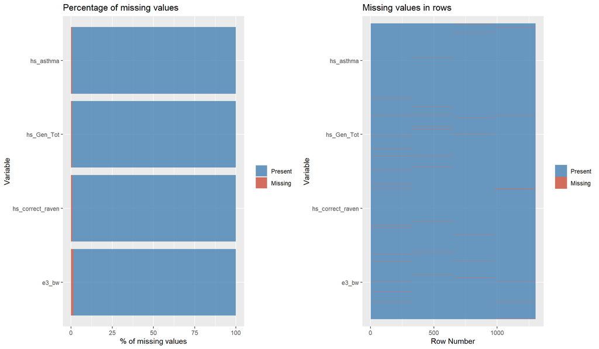

```r
grid::grid.newpage()
grid::grid.draw(missingness_plot)
```

```r
message(">>> Missing-values plots saved to: ", missingness_file)

# 5. Complete Cases Analysis Report
cc_matrix <- na.omit(df_)
message(paste0("\n>>> COMPLETE CASES ANALYSIS for PHENOTYPES:"))
message(paste0("    Original Dimensions: ", paste(dim(df_), collapse = " x ")))
message(paste0("    Complete Dimensions: ", paste(dim(cc_matrix), collapse = " x ")))
message(paste0("    Rows dropped: ", nrow(df_) - nrow(cc_matrix)))
# ------------------------------------------------------------------------------
```

Additionally, we will explore correlation patterns both in exposures and outcomes:

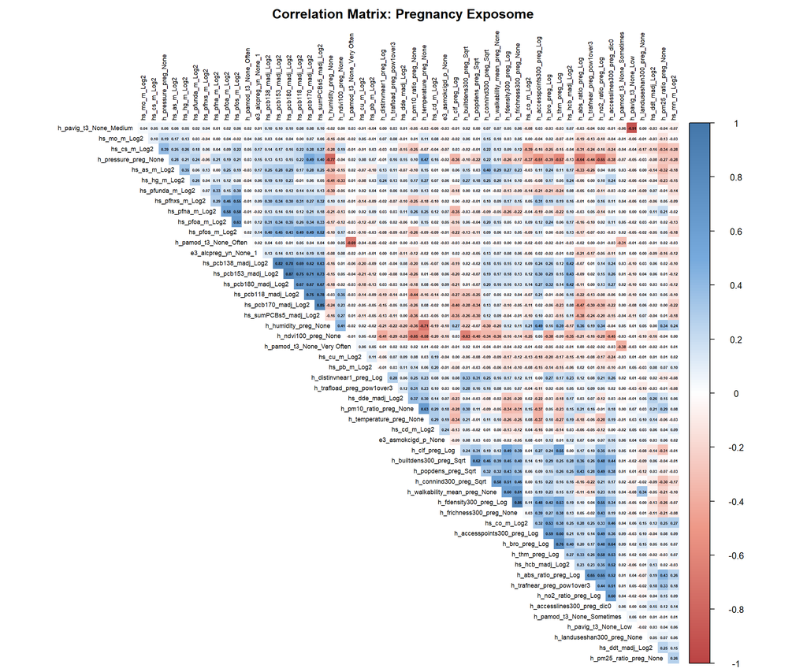

```r
# BLOCK 4: CORRELATION ANALYSIS (Corrplots)
# ------------------------------------------------------------------------------
message("\n>>> [Block 4] Generating Correlation Plots...")

# Plotting helper functions used below are defined in
# functions/msrrr_plotting_functions.R.

# Generate plots for all 3 datasets
generate_corrplot(
  X_preg, "Correlation Matrix: Pregnancy Exposome",
  file.path(results_dir, "CORRPLOT_predictors_Pregnancy.pdf"),
  label_cex = 0.55, number_cex = 0.35,
  display_in_current_device = TRUE
)
```

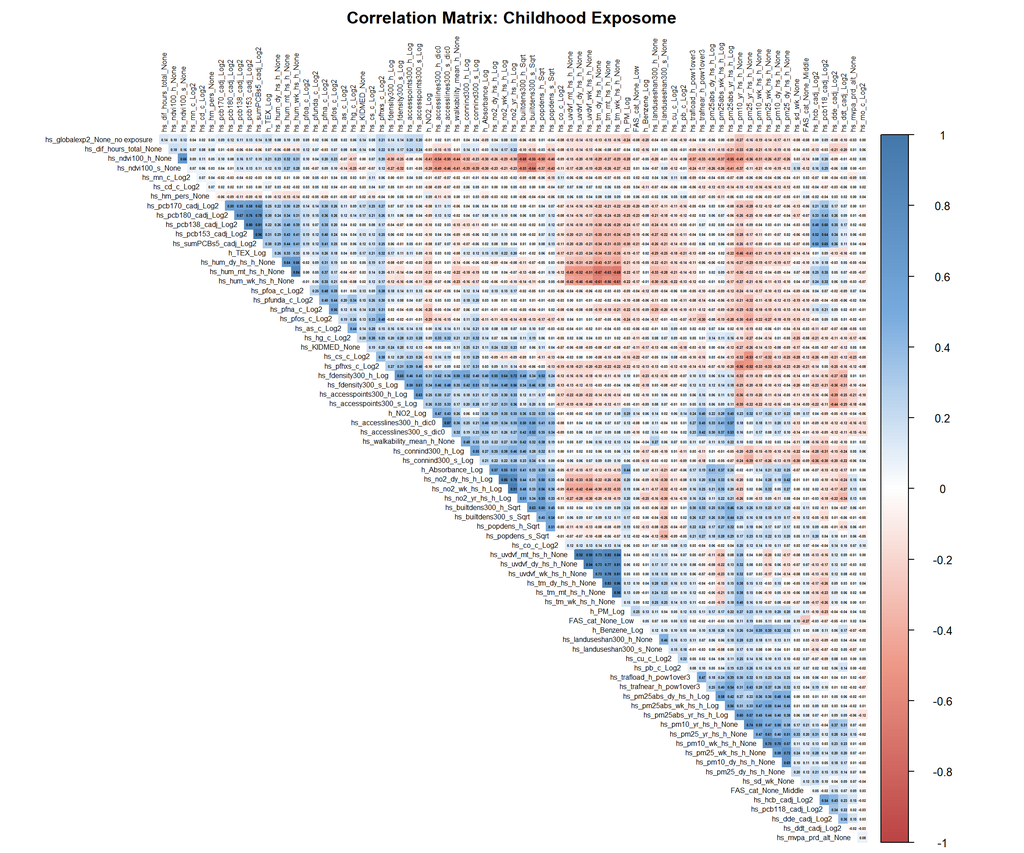

```r
generate_corrplot(
  X_child, "Correlation Matrix: Childhood Exposome",
  file.path(results_dir, "CORRPLOT_predictors_Childhood.pdf"),
  label_cex = 0.50, number_cex = 0.25,
  display_in_current_device = TRUE
)
```

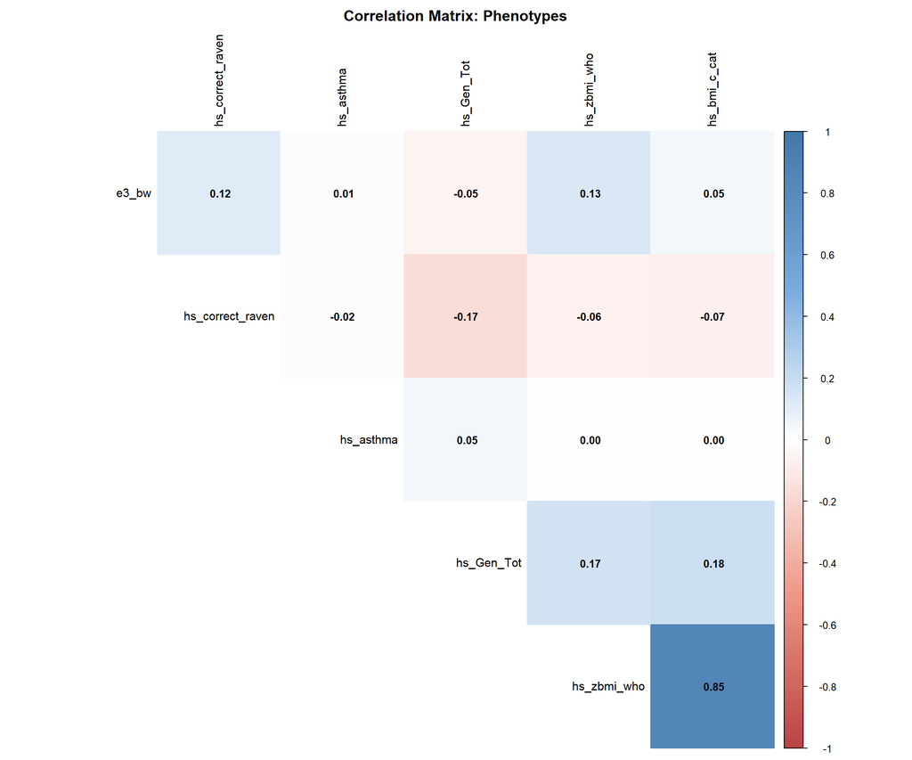

```r
generate_corrplot(
  Y, "Correlation Matrix: Phenotypes",
  file.path(results_dir, "CORRPLOT_Phenotypes.pdf"),
  label_cex = 0.95, number_cex = 0.85,
  display_in_current_device = TRUE
)
```

```r
# Save only the necessary processed matrices and the codebook info
save(X_preg, X_child, Z, Y, Y_df, vars_info,
     file = file.path(results_dir, "checkpoint_preproc.RData"))
# ------------------------------------------------------------------------------
```

# 6. EXPERIMENTAL DESIGN: The Validation Architecture

To prevent overfitting—a critical risk in high-dimensional studies—we implemented a strict **Three-Stage Validation Protocol**.

## Stage 1: Stratified Discovery Split (80/20)

The population was partitioned into a **Training Set (80%)** for model discovery and a **Test Set (20%)** for independent evaluation.

## Stage 2: Hyperparameter Tuning (5-Fold Cross-Validation)

Within the Training Set, we optimized the model’s hyperparameters: 1. **The Rank ($r$):** The number of latent biological pathways. 2. **The Penalty ($\lambda$):** The strength of the filter.

We used **5-Fold Cross-Validation (CV)**. The logic for 5-Fold (rather than 10) is to preserve a sufficient number of rare clinical events (e.g., asthma cases) in each validation fold, ensuring a stable estimate of the Deviance.

## Stage 3: The “Validate-then-Refit” Logic

Once the optimal hyperparameters ($Rank_{opt}, \lambda_{opt}$) were validated (confirmed by low pMSE in the Test Set), we refitted the final model using the **Whole Sample (100%)**.

- **Justification:** In epidemiology, our goal is inference. Using the full sample size maximizes statistical power to estimate the magnitude of the coefficients ($\beta$) accurately, while the previous steps ensured the *structure* of the model is not an artifact.

```r
# BLOCK 5: DATA SPLITTING & STRATIFICATION (Training/Test & Folds)
# ------------------------------------------------------------------------------
message(">>> [Block 5] Starting Data Splitting and Stratification...")

# 5.1 Configuration
# ------------------------------------------------------------------------------
set.seed(12345)
train_prop <- 0.8
num_folds  <- 5

# 5.2 Create Stratification Variable (Combined Asthma & BMI Category)
# ------------------------------------------------------------------------------
# We combine both variables to ensure balance in both.
# We handle NAs as a separate level so we don't lose any individuals.

# Temporary factors for stratification
s_asthma  <- ifelse(is.na(Y[, "hs_asthma"]), "NA", as.character(Y[, "hs_asthma"]))
s_bmi_cat <- ifelse(is.na(Y[, "hs_bmi_c_cat"]), "NA", as.character(Y[, "hs_bmi_c_cat"]))

# Create the interaction strata
combined_strata <- as.factor(paste(s_asthma, s_bmi_cat, sep = "_"))

message("    Strata distribution (Asthma_BMIcat):")
print(table(combined_strata))
```

```
combined_strata
 0_1  0_2  0_3  0_4  1_1  1_2  1_3  1_4 NA_2 NA_3 NA_4
  11  805  223  115    2   96   29   13    3    1    3
```

```r
# 5.3 Split Population (Training 80% / Test 20%)
# ------------------------------------------------------------------------------
# Using caret::createDataPartition to ensure the 80/20 split is balanced
train_index <- caret::createDataPartition(combined_strata, p = train_prop, list = FALSE)
train_index <- as.vector(train_index)

# Split Exposome
X_preg_train  <- X_preg[train_index, ]
X_preg_test   <- X_preg[-train_index, ]
X_child_train <- X_child[train_index, ]
X_child_test  <- X_child[-train_index, ]

# Split Covariates and Outcomes
Z_train  <- Z[train_index, ]
Z_test   <- Z[-train_index, ]
Y_train  <- Y[train_index, ]
Y_test   <- Y[-train_index, ]

message(paste("    Split complete. Training N:", nrow(Y_train), "| Test N:", nrow(Y_test)))

# 5.4 Generate Stratified Fold IDs for Cross-Validation
# ------------------------------------------------------------------------------
# We repeat the stratification logic inside the Training set for the 5 folds.
train_strata <- combined_strata[train_index]

# Create folds
folds_list <- caret::createFolds(train_strata, k = num_folds, list = TRUE)

# Initialize foldid vector
foldid <- numeric(nrow(Y_train))
for(i in seq_along(folds_list)) {
  foldid[folds_list[[i]]] <- i
}
# ------------------------------------------------------------------------------
# BLOCK 5.5: COMPACT BALANCE VERIFICATION (Fixed Alignment)
# ------------------------------------------------------------------------------
message("\n>>> [Block 5.5] Verifying Balance across Folds (Fixed Table)...")

# Variables to check
check_vars <- c("hs_asthma", "hs_bmi_c_cat")

for (var_ in check_vars) {
  message(paste0("\n--- Proportion Table for: ", var_, " ---"))

  # 1. Identify all possible levels (including NA) across the whole dataset
  # This ensures all tables have the same rows even if a fold is missing a category
  all_levels <- names(table(Y[, var_], useNA = "always"))

  # 2. Function to get consistent proportions per fold
  # Workflow helper functions used below are defined in functions/msrrr_tutorial_workflow_functions.R.

  # 3. Build the comparison matrix
  comp_matrix <- sapply(1:num_folds, function(f) {
    get_prop(Y_train[foldid == f, var_])
  })

  # 4. Add the Test Set column
  test_col <- get_prop(Y_test[, var_])
  final_tab <- cbind(comp_matrix, test_col)

  # 5. Formatting
  colnames(final_tab) <- c(paste0("Fold_", 1:num_folds), "Test_Set")
  rownames(final_tab) <- ifelse(is.na(all_levels), "Missing/NA", all_levels)

  print(final_tab)
}
```

```
           Fold_1 Fold_2 Fold_3 Fold_4 Fold_5 Test_Set
0           0.885   0.88  0.885  0.886  0.886    0.898
1           0.115   0.11  0.111  0.105  0.105    0.102
Missing/NA  0.000   0.01  0.005  0.010  0.010    0.000
```

```
           Fold_1 Fold_2 Fold_3 Fold_4 Fold_5 Test_Set
1           0.014  0.005  0.010  0.010  0.014    0.008
2           0.692  0.699  0.697  0.690  0.686    0.703
3           0.192  0.196  0.197  0.195  0.195    0.191
4           0.101  0.100  0.096  0.105  0.105    0.098
Missing/NA  0.000  0.000  0.000  0.000  0.000    0.000
```

```r
# ------------------------------------------------------------------------------
# BLOCK 5.6: FINAL DIMENSIONS & SPLIT SUMMARY
# ------------------------------------------------------------------------------
message("\n>>> Final sample distribution:")
print(table(foldid, dnn = "Fold ID"))
```

```
Fold ID
  1   2   3   4   5
208 209 208 210 210
```

```r
message(paste0("\n    Exposome Matrix (Train): ", nrow(X_child_train), " x ", ncol(X_child_train)))
message(paste0("    Exposome Matrix (Test):  ", nrow(X_child_test), " x ", ncol(X_child_test)))

message("\n>>> [Block 5] Step completed. The proportions are now perfectly aligned.")


# ------------------------------------------------------------------------------
# BLOCK 5.7: TEST SET PREPARATION FOR EVALUATION
# ------------------------------------------------------------------------------
# In a tutorial context, we want the Test Set to have ground truth values
# to calculate prediction metrics (RMSE, R2, etc.) later.

# We check if there are any samples in Y_test that present any NA
full_na_test <- rowSums(is.na(Y_test)) >= 1

if(any(full_na_test)) {
  message(paste(">>> Removing", sum(full_na_test), "subjects from Test set with NA outcome data."))

  X_preg_test  <- X_preg_test[!full_na_test, ]
  X_child_test <- X_child_test[!full_na_test, ]
  Z_test       <- Z_test[!full_na_test, ]
  Y_test       <- Y_test[!full_na_test, ]
}

# Note: Individual NAs within Y_test are fine, but when calculating metrics later,
# we will need to use functions that handle NAs (e.g., cor(..., use = "complete.obs")).

message(">>> Block 5 fully optimized for Model Evaluation.")
# ------------------------------------------------------------------------------
```

And we **check final dimensions** of produced datasets:

```r
# BLOCK 5.8: FINAL DATA INTEGRITY CHECK (Dimensions & Names)
# ------------------------------------------------------------------------------
message("\n>>> [Block 5.8] Final Data Integrity Check before Modeling...")

# 1. List of main datasets to inspect
# ------------------------------------------------------------------------------
datasets_to_check <- list(
  X_preg_train  = X_preg_train,
  X_preg_test   = X_preg_test,
  X_child_train = X_child_train,
  X_child_test  = X_child_test,
  Z_train       = Z_train,
  Z_test        = Z_test,
  Y_train       = Y_train,
  Y_test        = Y_test
)

# 2. Automated Inspection Loop
# ------------------------------------------------------------------------------
for (name in names(datasets_to_check)) {
  mat <- datasets_to_check[[name]]

  # Basic Info
  cat(paste0("\n--- Dataset: ", name, " ---\n"))
  cat(paste0("  [Dim]: ", nrow(mat), " rows x ", ncol(mat), " columns\n"))

  # Column check (First 10)
  all_cols <- colnames(mat)
  n_to_show <- min(10, length(all_cols))
  cat(paste0("  [First ", n_to_show, " vars]: ",
             paste(all_cols[1:n_to_show], collapse = ", "), "...\n"))

  # NA Check (Should be 0 for X and Z, but can have some in Y)
  n_nas <- sum(is.na(mat))
  if(n_nas > 0) {
    cat(paste0("  [Alert]: Found ", n_nas, " missing values (Expected in Y, check if in X/Z)\n"))
  }
}
```

```
--- Dataset: X_preg_train ---
  [Dim]: 1045 rows x 53 columns
  [First 10 vars]: h_abs_ratio_preg_Log, h_no2_ratio_preg_Log, h_pm10_ratio_preg_None, h_pm25_ratio_preg_None, h_accesslines300_preg_dic0, h_accesspoints300_preg_Log, h_builtdens300_preg_Sqrt, h_connind300_preg_Sqrt, h_fdensity300_preg_Log, h_frichness300_preg_None...

--- Dataset: X_preg_test ---
  [Dim]: 249 rows x 53 columns
  [First 10 vars]: h_abs_ratio_preg_Log, h_no2_ratio_preg_Log, h_pm10_ratio_preg_None, h_pm25_ratio_preg_None, h_accesslines300_preg_dic0, h_accesspoints300_preg_Log, h_builtdens300_preg_Sqrt, h_connind300_preg_Sqrt, h_fdensity300_preg_Log, h_frichness300_preg_None...

--- Dataset: X_child_train ---
  [Dim]: 1045 rows x 76 columns
  [First 10 vars]: hs_no2_dy_hs_h_Log, hs_no2_wk_hs_h_Log, hs_no2_yr_hs_h_Log, hs_pm10_dy_hs_h_None, hs_pm10_wk_hs_h_None, hs_pm10_yr_hs_h_None, hs_pm25_dy_hs_h_None, hs_pm25_wk_hs_h_None, hs_pm25_yr_hs_h_None, hs_pm25abs_dy_hs_h_Log...

--- Dataset: X_child_test ---
  [Dim]: 249 rows x 76 columns
  [First 10 vars]: hs_no2_dy_hs_h_Log, hs_no2_wk_hs_h_Log, hs_no2_yr_hs_h_Log, hs_pm10_dy_hs_h_None, hs_pm10_wk_hs_h_None, hs_pm10_yr_hs_h_None, hs_pm25_dy_hs_h_None, hs_pm25_wk_hs_h_None, hs_pm25_yr_hs_h_None, hs_pm25abs_dy_hs_h_Log...

--- Dataset: Z_train ---
  [Dim]: 1045 rows x 11 columns
  [First 10 vars]: h_mbmi_None, e3_gac_None, e3_sex_None, h_age_None, h_cohort_2, h_cohort_3, h_cohort_4, h_cohort_5, h_cohort_6, h_edumc_None_2...

--- Dataset: Z_test ---
  [Dim]: 249 rows x 11 columns
  [First 10 vars]: h_mbmi_None, e3_gac_None, e3_sex_None, h_age_None, h_cohort_2, h_cohort_3, h_cohort_4, h_cohort_5, h_cohort_6, h_edumc_None_2...

--- Dataset: Y_train ---
  [Dim]: 1045 rows x 6 columns
  [First 6 vars]: e3_bw, hs_asthma, hs_zbmi_who, hs_correct_raven, hs_Gen_Tot, hs_bmi_c_cat...
  [Alert]: Found 35 missing values (Expected in Y, check if in X/Z)

--- Dataset: Y_test ---
  [Dim]: 249 rows x 6 columns
  [First 6 vars]: e3_bw, hs_asthma, hs_zbmi_who, hs_correct_raven, hs_Gen_Tot, hs_bmi_c_cat...
```

```r
# 3. Validation Fold (foldid) Check
# ------------------------------------------------------------------------------
cat(paste0("\n--- Cross-validation folds: ", length(unique(foldid)), " folds ---\n"))
```

```
--- Cross-validation folds: 5 folds ---
```

```r
cat(paste0("  Length: ", length(foldid), " (Matches Y_train: ",
           length(foldid) == nrow(Y_train), ")\n"))
```

```
  Length: 1045 (Matches Y_train: TRUE)
```

```r
cat("  Frequency per fold:\n")
```

```
  Frequency per fold:
```

```r
print(table(foldid))
```

```
foldid
  1   2   3   4   5
208 209 208 210 210
```

```r
message("\n>>> [Integrity Check] Done. All datasets are aligned and ready.")
# ------------------------------------------------------------------------------
```

# 7. DATA HARMONIZATION: The “Leakage-Proof” Strategy and Mathematical Fairness

## 7.1 Why Standardization & Scaling Matter

**The Problem**: In exposome research, variables are measured in vastly different units (e.g., μg/L for blood chemicals vs. meters for proximity to green spaces). Because the msRRR model applies a strict Group-Lasso regularization penalty ($\lambda$) to filter variables, it would mathematically penalize exposures with naturally larger numerical ranges. Similarly, health outcomes span different domains (e.g., continuous metrics vs. binary status), risking that high-variance outcomes dominate the latent factors.

**The Solution**: msrrr_cv() internally harmonize the data before modeling to ensure all variables compete equally for selection:

- **Continuous predictors ($X$) and covariates ($Z$)**: Z-score standardization ($\mu=0$, $\sigma=1$).
- **Binary/dummy predictors and covariates**: kept on their original 0/1 scale.
- **Continuous Outcomes ($Y$)**: Z-score standardization ($\mu=0$, $\sigma=1$).
- **Binary Outcomes ($Y$)**: Explicit binarization (e.g., thresholding BMI categories strictly into 0 and 1).

## 7.2 Preventing Data Leakage

`msrrr_cv()` expects **analysis-ready but unscaled numeric matrices**. Variables must already be selected and coded, including dummy creation and scientifically defined binary recoding, but continuous X/Z columns must not be standardised and Gaussian outcomes must not be standardised before the function is called.

This interface allows preprocessing to be integrated into cross-validation. The transformation is learned from the training portion of each CV iteration and then applied unchanged to its validation fold. This keeps validation observations separate from the estimation of preprocessing parameters. The external 20% test set is handled analogously: it does not determine any transformation learned from the 80% development sample.

To ensure strict integrity and true external validity, we implemented a **Leakage-Proof harmonization strategy**:

1. **Within each CV iteration:** `msrrr_cv()` learns X/Z and Gaussian-Y means and standard deviations from the four training folds jointly.
2. **Internal validation:** those parameters are applied unchanged to the fifth fold. The validation fold never contributes to their estimation.
3. **Final 80% training fit:** after rank and lambda selection, preprocessing is learned again from the complete development sample and stored in the fitted object.
4. **External test:** `predict()` accepts the raw 20% test matrices and applies the stored 80% parameters automatically.
5. **Whole-sample refit:** `refit_msrrr()` learns a new transformation from all available subjects before fitting the final model.

This rigorous approach guarantees that the Test set remains completely naive and unseen, preserving the mathematical fairness of the regularization step.

```r
# BLOCK 5.9: RAW MATRICES FOR LEAKAGE-FREE INTERNAL CV
# ------------------------------------------------------------------------------
message(
  ">>> [Block 5.9] Keeping X, Z and Y untransformed for msrrr_cv()..."
)

# msrrr_cv() learns X/Z and Gaussian-Y z-score standardisation using
# only the four training folds in each CV iteration, then applies those
# parameters unchanged to the held-out validation fold. Its final training fit
# learns a new transformation from the complete 80% development sample.
# Binary X/Z columns remain 0/1.
#
# hs_bmi_c_cat is stored as four ordered categories (1-4), not as an existing
# dummy. Convert its scientifically defined lower/higher grouping explicitly
# before CV; this is recoding, not data-derived scaling.
# 0 (Under+Normal) vs 1 (Over+Obese)
Y_train[, "hs_bmi_c_cat"] <- as.numeric(Y_train[, "hs_bmi_c_cat"] >= 3)
Y_test[, "hs_bmi_c_cat"]  <- as.numeric(Y_test[, "hs_bmi_c_cat"] >= 3)

message("\n--- BMI recoding check (Train/Test) ---")
print(table(Y_train[, "hs_bmi_c_cat"], dnn = "Train_BMI_Binary"))
```

```
Train_BMI_Binary
  0   1
735 310
```

```r
print(table(Y_test[, "hs_bmi_c_cat"], dnn = "BMI_Binary"))
```

```
BMI_Binary
  0   1
176  73
```

```r
# ------------------------------------------------------------------------------
```

# 8. HYPERPARAMETER OPTIMIZATION: The Tune-Validate-Refit Logic

With the data strictly harmonized and secured against data leakage, we proceed to awaken the **msRRR** statistical engine. In this phase, the algorithm does not merely fit a single model; it explores a vast hyperparameter space to find the perfect equilibrium between biological complexity (Latent Rank $r$) and strict variable selection (Group-Lasso Penalty $\lambda$).

To capture the complexity of exposures across different developmental windows, we will sequentially evaluate three scenarios: **A) Pregnancy Exposome**, **B) Childhood Exposome**, and **C) Combined Exposome**.

## 8.1 The “Mixed-Response” Architecture and hyperparameter tunning

The true advantage of the msRRR framework is its multivariate, *Outcome-Wide* capability. Through the `family` and `familygroup` arguments, we mathematically map the statistical nature of each outcome into a single, unified response matrix. Continuous phenotypes (such as Birthweight or BMI z-score) are evaluated under a Gaussian link, while categorical phenotypes (such as Asthma status) are processed using a Binomial (Logit) link.

msRRR requires tuning **two hyperparameters**:

- **Rank (r)**: Number of latent biological pathways (typically 2-8)
- **Lambda (λ)**: Sparsity strength (controls how many exposures are selected)

**Why 5-Fold instead of 10-Fold?**

## 8.2 The Regularization Path: Defining $\lambda_{max}$ and the Sparsity Sequence

Before the model can select exposures, it needs a search grid for penalisation. When `lamseq = NULL`, the user does not need to choose numerical lambda limits. The function first calculates a data-driven reference value summarising the overall relationship between the exposures and outcomes. It then creates `nlam` values, evenly spaced on a logarithmic scale, from very strong to very weak penalisation. Exactly the same sequence is evaluated for every candidate rank and CV fold.

For reproducibility, the precise calculation is $\lambda_{\mathrm{reference}}=1.1\lVert X^TY\rVert_2/n$, where $\lVert X^TY\rVert_2$ is the largest singular value of $X^TY$. The tested sequence runs from $10\lambda_{\mathrm{reference}}$ down to $10^{-4}\lambda_{\mathrm{reference}}$.

**Lambda Search Space**:

- Automatic reference: `spectral_norm(crossprod(X, Y)) / n * 1.1`
- Logarithmic sequence from `reference_lambda * 10` down to `reference_lambda * 1e-4`
- One common sequence reused for every candidate rank and CV fold
- Alternatively, the user may provide an explicit `lamseq`

This automatic value is a practical starting point, not a guaranteed exact KKT boundary for the mixed-family, reduced-rank and non-convex msRRR problem. Therefore, after fitting, `msrrr_cv()` checks every candidate rank separately: whether its CV-optimal lambda is either endpoint and whether its largest tested lambda produces an exposure-free model. If coverage may be insufficient, the diagnostic identifies the affected ranks and prints a tenfold-extended common `lamseq`, with an integer length chosen to preserve approximately the existing log-scale resolution. The proposed grid is not fitted automatically; the user decides whether to rerun all ranks with it.

## 8.3 Cross-Validation and Predictive Performance (pMSE)

For each scenario, the model is trained using **K-fold Cross-Validation** (based on the stratified folds generated previously). The algorithm simultaneously evaluates `rank_sequence` and the complete lambda sequence, ultimately **selecting the rank/lambda combination that minimizes the chosen CV criterion**. By default, we keep `cv.criteria = "deviance"` to preserve the original mixed-response analysis. If all final outcomes are continuous, this can be switched to `cv.criteria = "pMSE"`.

The current `msrrr_cv()` implementation also audits rank/lambda boundaries, whether the selected model has fewer active exposures than its selected rank, response families, missing outcomes, weak outcome relationships and rare dummy predictors. For all-Gaussian analyses, the outcome-relationship check reports when more than half of the evaluable outcome pairs have $|r| < 0.25$. When the `.R` script is run directly, these messages and warnings remain visible in the console. This Rmd suppresses them in the rendered HTML to avoid clutter, but the diagnostic records remain stored in each fitted object and are saved in the scenario-specific file supplied through `diagnostics_file`.

Boundary diagnostics are recommendations for review, not automatic evidence that a model is invalid. The complete diagnostic curve should be considered. If stronger penalties clearly worsen the CV criterion, while the smallest lambdas give almost indistinguishable values and the selected model no longer changes, extending the path further may add little practical information. Conversely, a curve still improving materially at an endpoint should be extended. Because the criterion is minimised, higher values (or less-negative values when the displayed criterion is negative) indicate worse CV performance.

## 8.4 Validating on Unseen Data

Finally, we extract these optimal parameters and calculate the **pseudo Mean Squared Error (pMSE)** on both the Training partition and the unseen Test set. This pMSE is reported as a common predictive performance metric, even when deviance is used for CV selection. A low difference between these two metrics (`Perf_Dif`) will empirically confirm that our model has extracted real, generalizable biological patterns, successfully avoiding overfitting.

- Apply fixed (rank*, λ*) to predict Y_test from X_test
- Calculate prediction error (pMSE)
- If error is low, structure is valid; if high, model is overfitted

This validates that the model learned real patterns, not noise.

```r
# BLOCK 6: msRRR MODEL FITTING (Sequential Scenarios)
# ------------------------------------------------------------------------------
message(">>> [Block 6] Fitting Models for Pregnancy, Childhood, and Combined...")
```

```
>>> [Block 6] Fitting Models for Pregnancy, Childhood, and Combined...
```

```r
# 6.0 Shared Model Configuration
# ------------------------------------------------------------------------------
# Outcome Family Mapping:
# 1: Birthweight (Gaussian), 2: Asthma (Binomial), 3: zBMI (Gaussian),
# 4: Raven (Gaussian), 5: Gen_Health (Gaussian), 6: Binary BMI Cat (Binomial)
outcome_families <- list(gaussian(), binomial())
family_mapping   <- c(1, 2, 1, 1, 1, 2)

# Lambda and rank options:
# - nrankseq contains the candidate ranks compared by CV.
# - Supply lamseq explicitly to test a user-defined lambda sequence.
# - With lamseq = NULL, msrrr_cv() obtains a data-driven reference summarising
#   the overall X-Y relationship, then creates nlam log-spaced values from very
#   strong to very weak penalisation. The same grid is used for all ranks and
#   folds. Technically, it spans from 10 times the reference lambda down to
#   1e-4 times that reference. nlam is ignored when lamseq is supplied.
#   Lambdas are ordered largest to smallest.
# - Lambda coverage is checked separately for every rank. If needed, the
#   warning prints a tenfold-extended common lamseq for a manual rerun of all
#   ranks; the function does not expand or rerun the grid automatically.
#
# CV and diagnostics:
# - foldid fixes the fold assignment; nfold must match its number of levels.
# - cv.criteria selects "deviance" or "pMSE".
# - diagnostics = TRUE runs and stores checks in fit$diagnostics.
# - print_diagnostics_at_end = TRUE prints their compact end-of-fit summary.
# - diagnostics_file is optional; when a path is supplied, the same audit is
#   also written to CSV. Use NULL if no separate file is required.
# - progress = FALSE suppresses the console-style progress bar in the rendered
#   HTML. The standalone R script uses progress = TRUE instead.
# - control$trace = TRUE is much more verbose and is intended for debugging.

# TECHNICAL NOTE ON MISSING Y VALUES DURING AUTOMATIC LAMBDA CALCULATION:
# crossprod() and svd() cannot operate with NA values. When lamseq = NULL,
# msrrr_cv() creates a temporary copy of Y and replaces missing entries with
# their observed outcome-column mean solely to calculate the initial lambda
# range. This temporary replacement is not used to fit the models and does not
# modify the original outcome matrix or its missing values.
```

```r
# ------------------------------------------------------------------------------
# 6.1 SCENARIO A: PREGNANCY EXPOSOME ONLY
# ------------------------------------------------------------------------------
message("\n>>> Scenario A: Fitting Pregnancy Model...")
```

```
>>> Scenario A: Fitting Pregnancy Model...
```

```r
cv.crit_preg <- "deviance"
# cv.crit_preg <- "pMSE"

fit_preg <- msrrr_cv(
  Y = Y_train, X = X_preg_train, Z = Z_train,
  family = outcome_families, familygroup = family_mapping,
  nrankseq = rank_sequence, lamseq = NULL, nlam = n_lambda,
  foldid = foldid, nfold = num_folds,
  method = "CV", cv.criteria = cv.crit_preg, warm = FALSE,
  diagnostics = TRUE, print_diagnostics_at_end = TRUE, progress = FALSE,
  diagnostics_file = file.path(results_dir, "MSRRR_CV_DIAGNOSTICS_PREGNANCY.csv")
)
```

```
>>> END-OF-RUN msRRR CV DIAGNOSTIC AUDIT
```

```
[MESSAGE] No lambda sequence supplied. A common sequence is calculated from the complete development sample after preprocessing; it is then reused unchanged in every CV fold.
```

```
[WARNING] The final penalised model selects 0 exposure(s), fewer than its selected rank (1). Its coefficient matrix can therefore have effective rank at most 0, so one or more latent components are redundant. Consider including lower ranks in nrankseq and reviewing the CV results.
```

```
[WARNING] CV selects the largest lambda for rank(s) 1, 2, 3, 4. The common lambda grid may not cover the optimum for every rank. Rerun all ranks with the following common sequence (30 total lambda values, preserving approximately the current log-scale resolution):
lamseq <- 10^seq(log10(1.8038e+02), log10(1.8038e-04), length.out = 30L)
```

```r
# ------------------------------------------------------------------------------
# 6.2 SCENARIO B: CHILDHOOD EXPOSOME ONLY
# ------------------------------------------------------------------------------
message("\n>>> Scenario B: Fitting Childhood Model...")
```

```
>>> Scenario B: Fitting Childhood Model...
```

```r
cv.crit_child <- "deviance"
# cv.crit_child <- "pMSE"

fit_child <- msrrr_cv(
  Y = Y_train, X = X_child_train, Z = Z_train,
  family = outcome_families, familygroup = family_mapping,
  nrankseq = rank_sequence, lamseq = NULL, nlam = n_lambda,
  foldid = foldid, nfold = num_folds,
  method = "CV", cv.criteria = cv.crit_child, warm = FALSE,
  diagnostics = TRUE, print_diagnostics_at_end = TRUE, progress = FALSE,
  diagnostics_file = file.path(results_dir, "MSRRR_CV_DIAGNOSTICS_CHILDHOOD.csv")
)
```

```
>>> END-OF-RUN msRRR CV DIAGNOSTIC AUDIT
```

```
[MESSAGE] No lambda sequence supplied. A common sequence is calculated from the complete development sample after preprocessing; it is then reused unchanged in every CV fold.
```

```
[WARNING] The selected rank (4) is the largest value tested. Consider extending nrankseq upward and refitting with the same CV folds. The maximum feasible rank is 6.
```

```r
# ------------------------------------------------------------------------------
# 6.3 SCENARIO C: COMBINED EXPOSOME (Pregnancy + Childhood)
# ------------------------------------------------------------------------------
message("\n>>> Scenario C: Fitting Combined Model...")
```

```
>>> Scenario C: Fitting Combined Model...
```

```r
# Concatenating sources to evaluate joint effects
X_combined_train <- cbind(X_preg_train, X_child_train)

cv.crit_comb <- "deviance"
# cv.crit_comb <- "pMSE"

fit_comb <- msrrr_cv(
  Y = Y_train, X = X_combined_train, Z = Z_train,
  family = outcome_families, familygroup = family_mapping,
  nrankseq = rank_sequence, lamseq = NULL, nlam = n_lambda,
  foldid = foldid, nfold = num_folds,
  method = "CV", cv.criteria = cv.crit_comb, warm = FALSE,
  diagnostics = TRUE, print_diagnostics_at_end = TRUE, progress = FALSE,
  diagnostics_file = file.path(results_dir, "MSRRR_CV_DIAGNOSTICS_COMBINED.csv")
)
```

```
>>> END-OF-RUN msRRR CV DIAGNOSTIC AUDIT
```

```
[MESSAGE] No lambda sequence supplied. A common sequence is calculated from the complete development sample after preprocessing; it is then reused unchanged in every CV fold.
```

```
[WARNING] The selected rank (4) is the largest value tested. Consider extending nrankseq upward and refitting with the same CV folds. The maximum feasible rank is 6.
```

```r
# ------------------------------------------------------------------------------
# BLOCK 7.1: INITIALIZE RESULTS SUMMARY TABLE
# ------------------------------------------------------------------------------
message(">>> [Block 7.1] Summarizing Model Results...")
```

```
>>> [Block 7.1] Summarizing Model Results...
```

```r
# 1. Prepare Joint Test Matrix for Scenario C
X_combined_test <- cbind(X_preg_test, X_child_test)

# 2. Initialize the results dataframe
results_df <- data.frame(
  Scenario      = c("Pregnancy", "Childhood", "Combined"),
  Seed          = rep(12345, 3),
  Opt_Rank      = rep(NA, 3),
  Opt_Lambda    = rep(NA, 3),
  N_Exposures   = rep(NA, 3),
  CV_Crit_Name   = c(cv.crit_preg, cv.crit_child, cv.crit_comb),
  CV_Crit_value   = rep(NA, 3),
  pMSE_training = rep(NA, 3),
  pMSE_test     = rep(NA, 3)
)

# 3. Helper function to fill the table
# Workflow helper functions used below are defined in functions/msrrr_tutorial_workflow_functions.R.

fill_results(1, fit_preg)
fill_results(2, fit_child)
fill_results(3, fit_comb)



# ------------------------------------------------------------------------------
# BLOCK 7.2: PREDICTION PERFORMANCE (pMSE)
# ------------------------------------------------------------------------------
message(">>> [Block 7.2] Calculating pMSE for Training and Test sets...")
```

```
>>> [Block 7.2] Calculating pMSE for Training and Test sets...
```

```r
# Scenario A: Pregnancy
fit_train_preg <- predict(
  fit_preg,
  Y.new = Y_train, X.new = X_preg_train, Z.new = Z_train,
  family = outcome_families, familygroup = family_mapping,
  cv.criteria = "pMSE"
)
fit_test_preg <- predict(
  fit_preg,
  Y.new = Y_test, X.new = X_preg_test, Z.new = Z_test,
  family = outcome_families, familygroup = family_mapping,
  cv.criteria = "pMSE"
)
results_df$pMSE_training[1] <- fit_train_preg$pred.perf
results_df$pMSE_test[1]     <- fit_test_preg$pred.perf

# Scenario B: Childhood
fit_train_child <- predict(
  fit_child,
  Y.new = Y_train, X.new = X_child_train, Z.new = Z_train,
  family = outcome_families, familygroup = family_mapping,
  cv.criteria = "pMSE"
)
fit_test_child <- predict(
  fit_child,
  Y.new = Y_test, X.new = X_child_test, Z.new = Z_test,
  family = outcome_families, familygroup = family_mapping,
  cv.criteria = "pMSE"
)
results_df$pMSE_training[2] <- fit_train_child$pred.perf
results_df$pMSE_test[2]     <- fit_test_child$pred.perf

# Scenario C: Combined
fit_train_comb <- predict(
  fit_comb,
  Y.new = Y_train, X.new = X_combined_train, Z.new = Z_train,
  family = outcome_families, familygroup = family_mapping,
  cv.criteria = "pMSE"
)
fit_test_comb <- predict(
  fit_comb,
  Y.new = Y_test, X.new = X_combined_test, Z.new = Z_test,
  family = outcome_families, familygroup = family_mapping,
  cv.criteria = "pMSE"
)
results_df$pMSE_training[3] <- fit_train_comb$pred.perf
results_df$pMSE_test[3]     <- fit_test_comb$pred.perf

results_df$Perf_Dif <- abs(results_df$pMSE_training - results_df$pMSE_test)
print(results_df)
```

```
   Scenario  Seed Opt_Rank Opt_Lambda N_Exposures CV_Crit_Name CV_Crit_value
1 Pregnancy 12345        1 18.0375006           0     deviance      2436.542
2 Childhood 12345        4  0.1895369          66     deviance      2383.285
3  Combined 12345        4  0.2389580         100     deviance      2393.208
  pMSE_training pMSE_test     Perf_Dif
1     0.7757534 0.7755135 0.0002399881
2     0.6850176 0.7291327 0.0441150375
3     0.6744686 0.7318792 0.0574106228
```

```r
# Save the primary model objects and the final results table
save(fit_preg, fit_child, fit_comb, results_df,
     file = file.path(results_dir, "msrrr_objects_model_metrics_results_training_CV.RData"))


write.csv2(results_df, file.path(results_dir, "model_metrics_results_training_CV.csv"), row.names = FALSE)


# ------------------------------------------------------------------------------
```

## 8.5 Visualizing the Optimization Space: Diagnostic Plots

After cross-validation, it is essential to visually verify the model’s learning behavior to ensure it has reached a stable global optimum rather than a localized artifact. We generate two key diagnostic plots:

1. **Rank vs. selected CV criterion:** This evaluates the structural complexity of the model. It shows how increasing the number of latent factors (biological pathways) affects the selected CV metric (`deviance` by default, or `pMSE` if selected). The optimal rank sits at the “elbow,” capturing maximum variance without overfitting.
2. **The Regularization Path (Lambda):** For the optimal rank, we plot the selected CV criterion across all CV folds for the entire logarithmic $\lambda$ sequence. This visualizes the classic bias-variance tradeoff. A well-behaved path will show a clear minimum, confirming that the Group-Lasso penalty has successfully filtered out the noise.

```r
# BLOCK 7.3: DIAGNOSTIC PLOTS (Generalized Function)
# ------------------------------------------------------------------------------

message(">>> [Block 7.3] Defining and generating Diagnostic Plots...")

# Function to generate Rank and Lambda diagnostics for any scenario
# Plotting helper functions used below are defined in functions/msrrr_plotting_functions.R.

# Example: Generate plots for each scenario
diag_preg  <- generate_diagnostics(fit_preg, "Pregnancy", cv.crit = cv.crit_preg)
diag_child <- generate_diagnostics(fit_child, "Childhood", cv.crit = cv.crit_child)
diag_comb  <- generate_diagnostics(fit_comb, "Combined", cv.crit = cv.crit_comb)

pdf(file.path(results_dir, "Model_Diagnostics_training_CV.pdf"), width = 8.5, height = 11)
plot(diag_preg)
plot(diag_child)
plot(diag_comb)
dev.off()
```

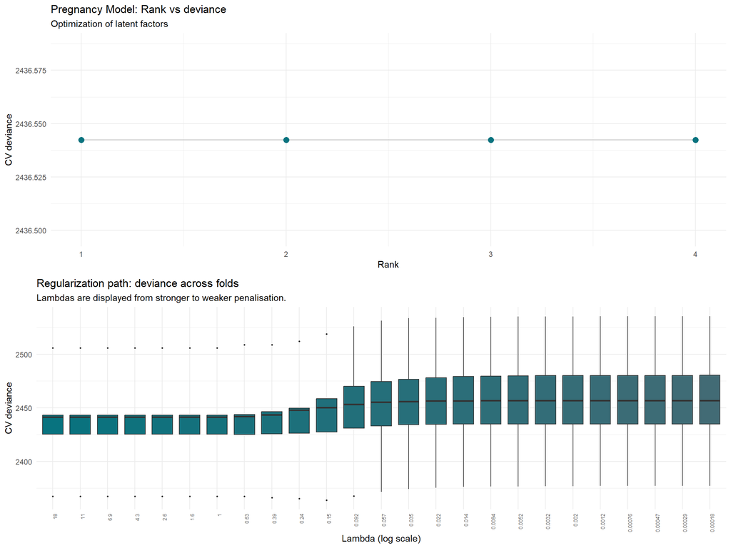

```r
# Display the same diagnostics in the rendered HTML.
grid::grid.newpage()
grid::grid.draw(diag_preg)
```

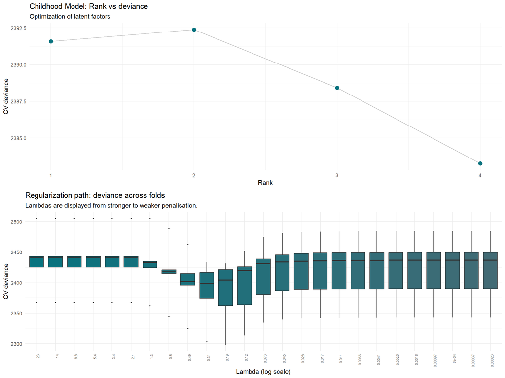

```r
grid::grid.newpage()
grid::grid.draw(diag_child)
```

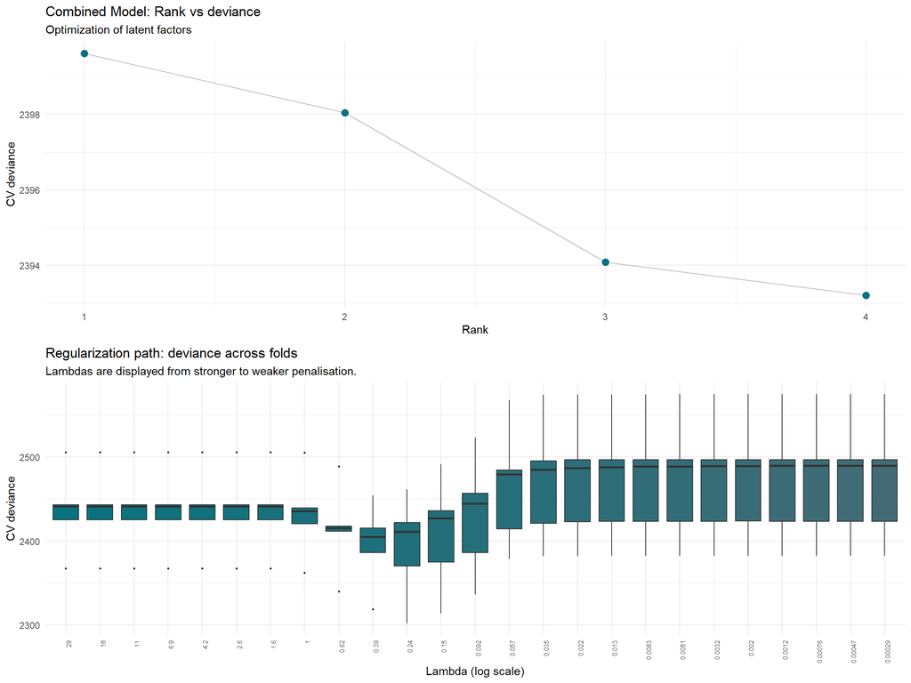

```r
grid::grid.newpage()
grid::grid.draw(diag_comb)
```

```r
# ------------------------------------------------------------------------------
# BLOCK 7.4: COEFFICIENT LOLLIPOP PLOTS (Top Exposures)
# ------------------------------------------------------------------------------
message(">>> [Block 7.4] Plotting Coefficients for Key Outcomes...")

# Plotting helper functions used below are defined in functions/msrrr_plotting_functions.R.

pdf(file.path(results_dir, "Coefficient_Lollipop_Plots_training_CV.pdf"), width = 12, height = 8)
coefficient_plots <- list()
coefficient_plot_scenarios <- list(
  Pregnancy = list(fit = fit_preg, X = X_preg_train),
  Childhood = list(fit = fit_child, X = X_child_train),
  Combined = list(fit = fit_comb, X = X_combined_train)
)
for (scenario_label in names(coefficient_plot_scenarios)) {
  scenario <- coefficient_plot_scenarios[[scenario_label]]
  for (outcome_idx in seq_len(ncol(Y_train))) {
    coefficient_plot <- plot_coeffs(
      scenario$fit, outcome_idx, scenario$X, scenario_label
    )
    if (!is.null(coefficient_plot)) {
      plot_name <- paste(scenario_label, outcome_idx, sep = "_")
      coefficient_plots[[plot_name]] <- coefficient_plot
      print(coefficient_plot)
    }
  }
}
dev.off()
```

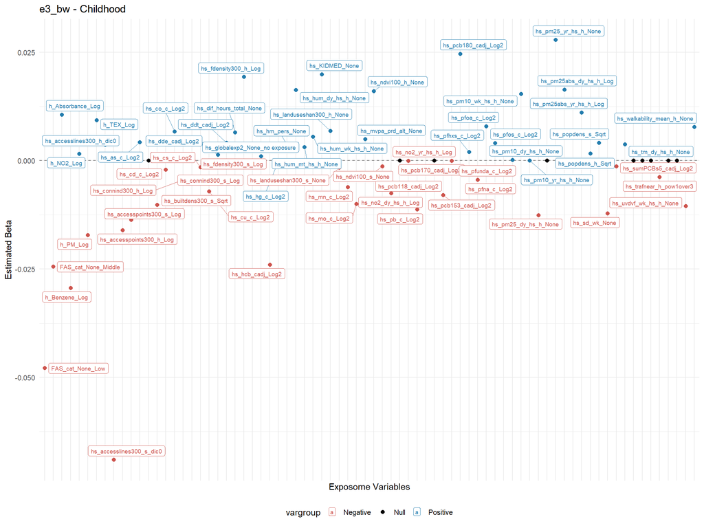

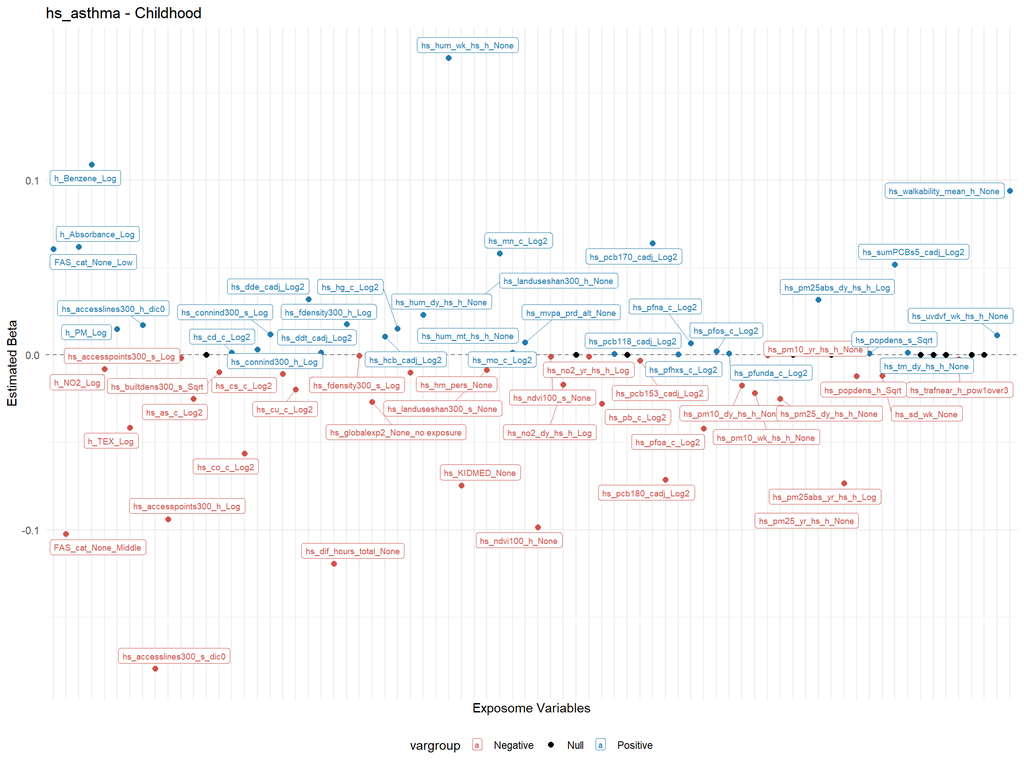

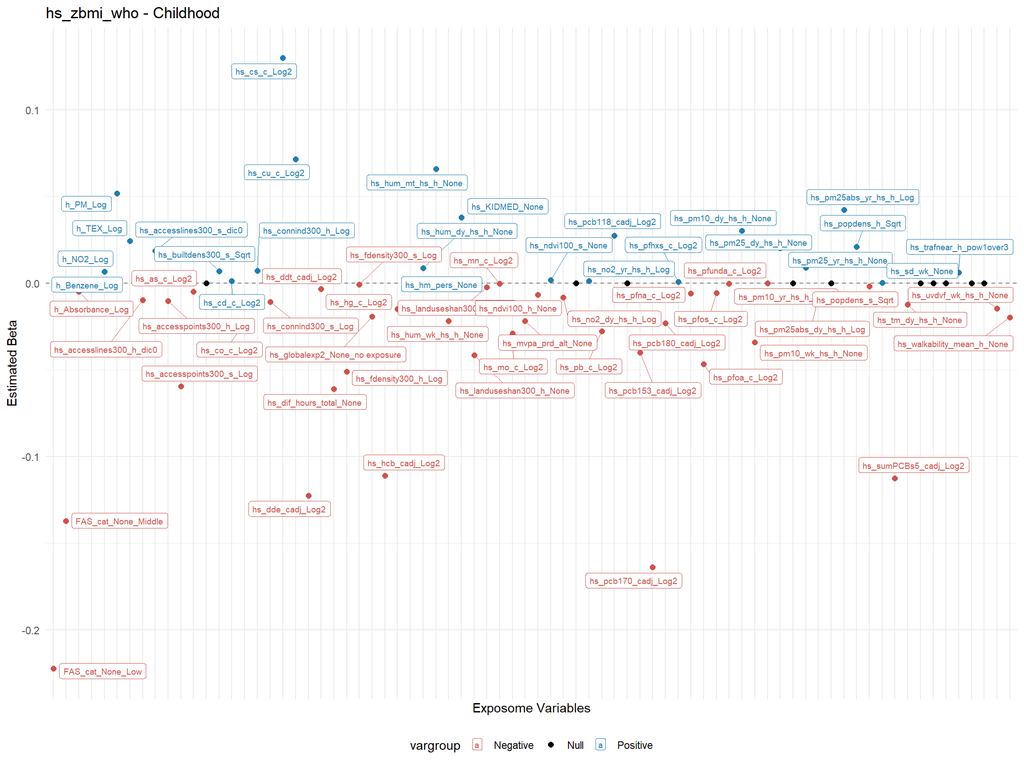

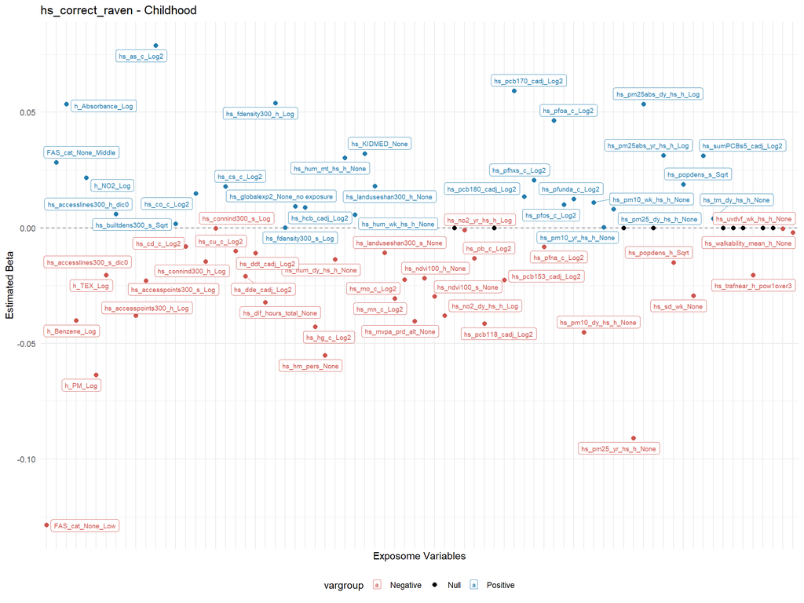

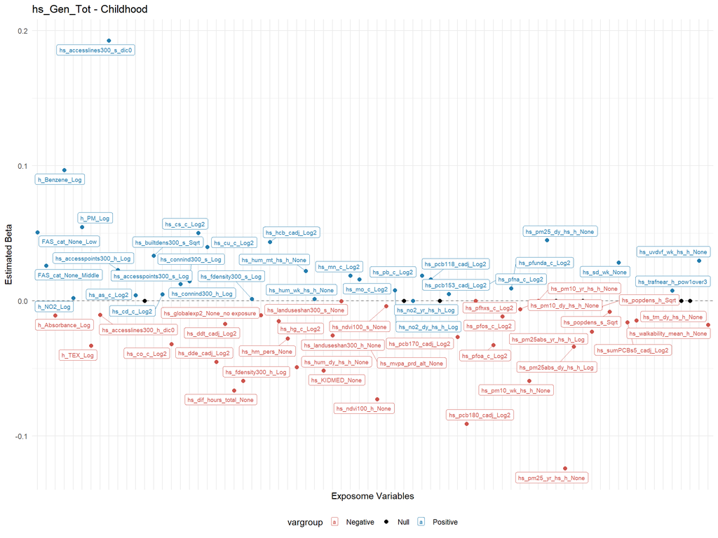

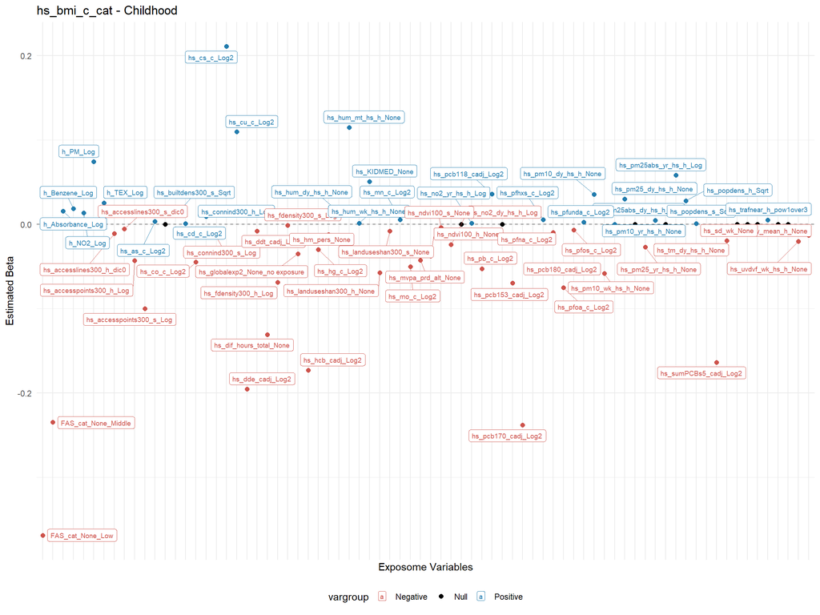

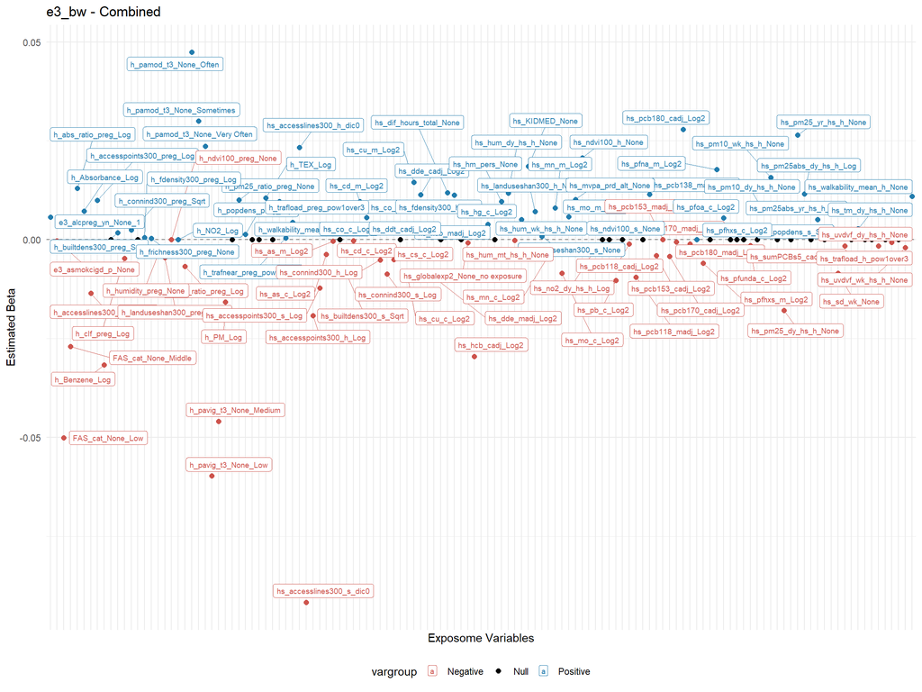

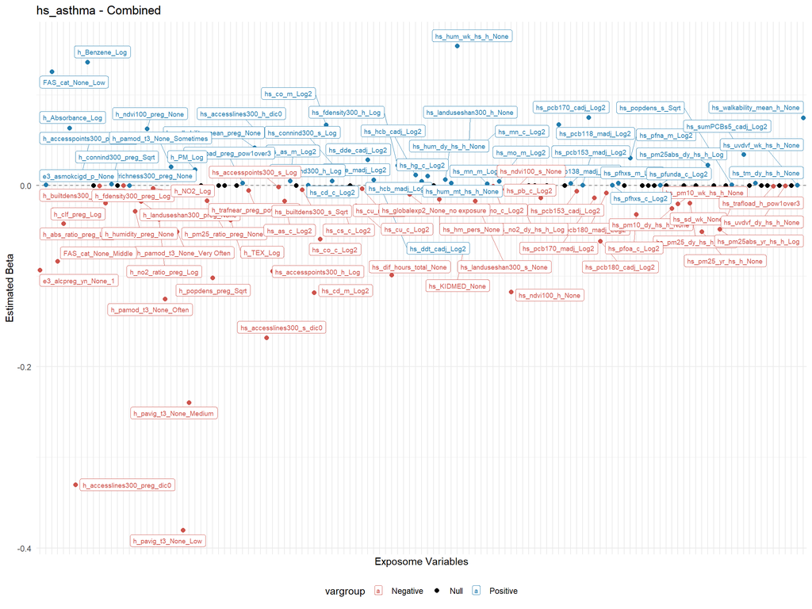

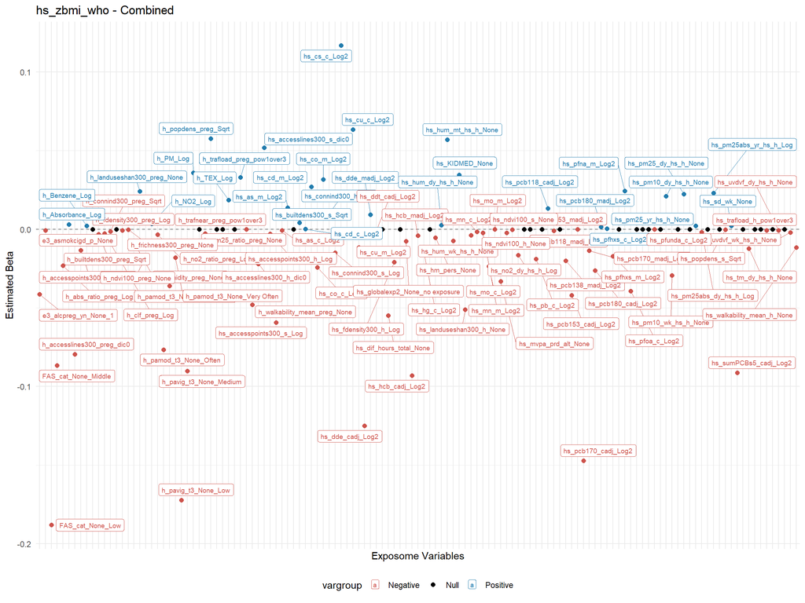

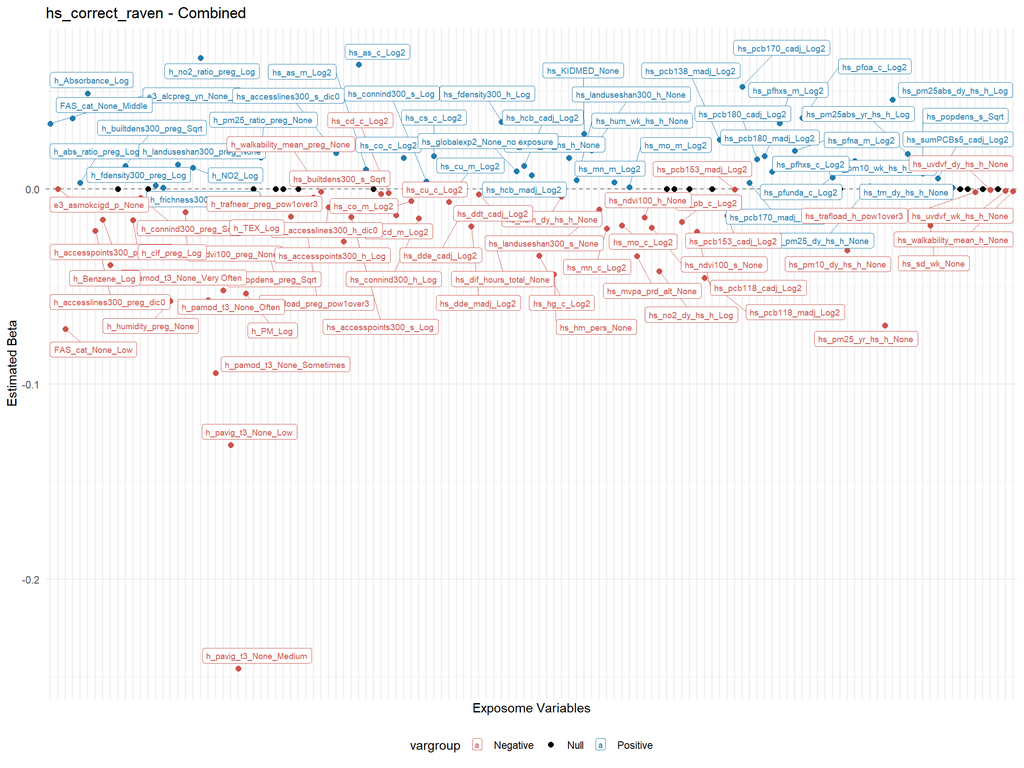

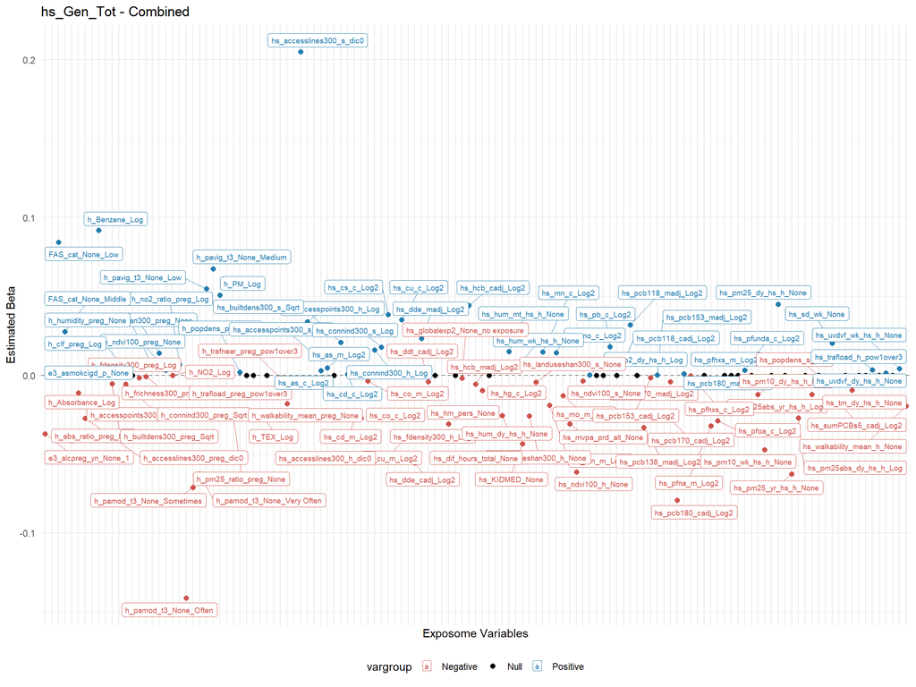

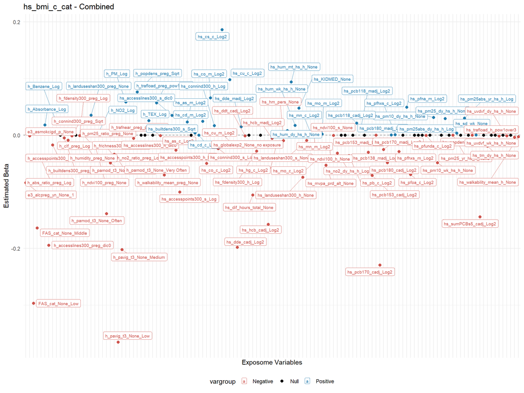

```r
# Display the same lollipop plots in the rendered HTML.
for (coefficient_plot in coefficient_plots) print(coefficient_plot)
```

```r
# ------------------------------------------------------------------------------
```

**Interpretation of the lambda path.** Across the fitted scenarios, decreasing lambda towards the weakly penalised end produced little or no further improvement in cross-validated deviance, indicating that this part of the path had already reached an approximate performance plateau. Conversely, increasing lambda towards stronger penalisation led to a clear deterioration in CV deviance. On the basis of these observed trends, we did not extend the grid further towards either an exactly unpenalised fit (`lambda = 0`) or a fully penalised model with no selected exposures. The reported grid therefore focuses on the empirically relevant region of the regularisation path; this decision is based on the shape of the CV curves rather than on both theoretical endpoint models having been explicitly fitted.

Finally, we extract these optimal parameters and calculate the **pseudo Mean Squared Error (pMSE)** on both the Training partition and the unseen Test set.

```r
# Prediction performance is executed in canonical Block 7.2 above.
```

## 8.6 The Outcome-Wide Environmental Signature: Global Heatmaps

This block generates the culmination of the training phase: the global coefficient matrix ($\mathbf{B}$). By visualizing all exposures and all outcomes simultaneously, we can identify **pleiotropic environmental factors**—exposures that act as “master drivers,” impacting multiple biological domains at once.

**Methodological Note on Interpretation:** Because we harmonized our data beforehand, coefficient interpretation depends on predictor type:

- **Continuous predictors:** a one-unit change corresponds to one training-sample SD.
- **Dummy predictors:** a one-unit change compares category 1 with category 0 because dummies remain unstandardised.
- **Continuous outcomes (Gaussian):** a one-unit change corresponds to one training-sample SD.
- **Binary outcomes (Binomial):** coefficients are on the log-odds scale and $e^\beta$ is an odds ratio.
- *Are they comparable?* Continuous-outcome coefficients are comparable in SD units. Binomial coefficients remain on the log-odds scale and are not directly comparable with Gaussian coefficients.

**Visualization Strategy (The Sharp Palette):** In sparse modeling, visualizing exactly what is zero and what is not is critical. We designed a custom “Sharp” color palette where *absolute zero* is strictly coded as Grey. The color ramps (Red for positive/risk, Green for negative/protective) are mapped in a way that avoids fading into white for small values. This ensures that any variable that survived the regularization penalty, no matter how small its effect size, is visibly active in the signature.

```r
# BLOCK 8: PROFESSIONAL COEFFICIENT HEATMAPS (With Interpretation Guide)
# ------------------------------------------------------------------------------

message(">>> [Block 8] Generating custom heatmaps and documentation...")

# 8.0 TECHNICAL NOTE: INTERPRETING msRRR COEFFICIENTS (Beta)
# ------------------------------------------------------------------------------
# 1. CONTINUOUS OUTCOMES (e.g., Birthweight, zBMI):
#    Continuous outcomes and predictors are z-score standardised. Beta is the
#    change in outcome SDs associated with a 1-SD increase in a continuous
#    exposure, adjusted for covariates. Beta = 0.1 means an increase of 0.1
#    outcome SDs per 1-SD increase in the exposure.
#
# 2. BINARY OUTCOMES (e.g., Asthma, BMI Category):
#    These use a Logit link. Beta represents the change in the LOG-ODDS of
#    the outcome for every 1 SD increase in exposure.
#    Exp(Beta) would provide the Odds Ratio (OR).
#    Beta = 0.4 means: OR = exp(0.4) ≈ 1.50 (a 50% increase in risk).

# 3. ARE EFFECT SIZES COMPARABLE?
#    Technically, NO. Beta_gaussian and Beta_binomial are on different scales
#    (Linear vs. Logit). However, within this msRRR framework, they are
#    comparable in terms of "Selection Strength": the penalty treats them
#    similarly to find the most influential predictors across all domains. A strong color in both indicates the exposure is a powerful
#      driver for both health domains, regardless of the unit.
# ------------------------------------------------------------------------------


# 8.1 CUSTOM "SHARP" COLOR PALETTE (GREENS AND REDS)
# ------------------------------------------------------------------------------
# Define two gradients that do NOT pass through white or yellow.
# Negative (green): dark green to light green
neg_palette <- colorRampPalette(c("#1A9850", "#A6DBA0"))(50)
# Neutral: grey (only for exact zero)
zero_color  <- "grey"
# Positive (red): light red to dark red
pos_palette <- colorRampPalette(c("#F4A582", "#D73027"))(50)

custom_colors_pro <- c(neg_palette, zero_color, pos_palette)

# 8.2 CUSTOM BREAKS (KEEPING NON-ZERO VALUES COLOURED)
# ------------------------------------------------------------------------------
# Plotting helper functions used below are defined in functions/msrrr_plotting_functions.R.

# 8.3 HEATMAP GENERATION FUNCTION
# ------------------------------------------------------------------------------
# Plotting helper functions used below are defined in functions/msrrr_plotting_functions.R.

# 8.4 Export
# ------------------------------------------------------------------------------
cv_heatmap_grobs <- list(
  plot_final_heatmap(fit_preg, X_preg_train, "Pregnancy", draw = FALSE)$gtable,
  plot_final_heatmap(fit_child, X_child_train, "Childhood", draw = FALSE)$gtable,
  plot_final_heatmap(fit_comb, X_combined_train, "Combined", draw = FALSE)$gtable
)
save_grobs_pdf(
  cv_heatmap_grobs,
  file.path(results_dir, "Exposome_Signatures_training_CV.pdf"),
  width = 18, height = 30
)
cv_heatmap_models <- list(PREGNANCY = fit_preg, CHILDHOOD = fit_child, COMBINED = fit_comb)
for (i in seq_along(cv_heatmap_grobs)) {
  scenario_name <- names(cv_heatmap_models)[i]
  save_grob_svg(
    cv_heatmap_grobs[[i]],
    file.path(results_dir, paste0("Exposome_Signatures_training_CV_", scenario_name, ".svg")),
    width = 18,
    height = heatmap_canvas_height(model_heatmap_n_rows(cv_heatmap_models[[i]]))
  )
}
message(">>> Block 8 Complete. Heatmaps updated with non-linear scale.")

# Display the same compact SVGs in the rendered HTML. Pass all paths to
# include_graphics() in one call: printing individual knit_image_paths objects
# inside a loop does not reliably emit figures in the knitted document.
cv_heatmap_html_paths <- file.path(
  results_dir,
  paste0(
    "Exposome_Signatures_training_CV_",
    names(cv_heatmap_models), ".svg"
  )
)
knitr::include_graphics(cv_heatmap_html_paths)
```

[figure not shown]

```r
load(file.path(results_dir, "msrrr_objects_model_metrics_results_training_CV.RData"))
results_df <- read.csv2(file.path(results_dir, "model_metrics_results_training_CV.csv"))
# ------------------------------------------------------------------------------
```

# 9. WHOLE SAMPLE REFIT FOR MAXIMUM INFERENCE POWER

Once the optimal hyperparameters ($Rank_{opt}, \lambda_{opt}$) were validated (confirmed by low pMSE in the Test Set), we refitted the final model using the **Whole Sample (100%)**.

## 9.1 The “Validate-then-Refit” Logic

**Key Principle**: In epidemiology, we seek **biological inference**, not prediction.

After cross-validation selects the rank and lambda in the 80% training sample, predictive performance is evaluated once in the independent 20% test sample. The selected structure is then refitted using **100% of the data** to:

- use all available information for the final coefficient estimates;
- obtain the whole-sample models used by both post-selection approaches; and
- provide the base models for the subsequent bootstrap analyses.

The previously reported test performance still refers to the untouched 20% evaluation step; it is not recalculated from the whole-sample refit.

```r
# BLOCK 9: SHARED PENALISED WHOLE-SAMPLE MODELS
# ------------------------------------------------------------------------------
# These are the main whole-sample models reported in Approach A. Their selected
# exposure subsets also define the candidate exposures that are subsequently
# refitted with lambda = 0 in Approach B. Block 9 is therefore required for
# BOTH approaches.
message(">>> [Block 9] Fitting shared penalised whole-sample models...")
# ------------------------------------------------------------------------------
set.seed(12345)

# 9.1 Prepare Whole Sample Matrices
# ------------------------------------------------------------------------------
outcome_families <- list(gaussian(), binomial())
family_mapping   <- c(1, 2, 1, 1, 1, 2)

# Supply raw matrices to refit_msrrr(). Because the CV objects contain
# preprocessing metadata, the refit learns new parameters from all subjects.
Y_whole_raw <- Y
Y_whole_raw[, "hs_bmi_c_cat"] <- as.numeric(
  Y_whole_raw[, "hs_bmi_c_cat"] >= 3
)
X_preg_whole_raw <- X_preg
X_child_whole_raw <- X_child
X_comb_whole_raw <- cbind(X_preg, X_child)
Z_whole_raw <- Z

# 9.2 Refit Final Models
# ------------------------------------------------------------------------------
# Reuse the exact initial values stored by msrrr_cv(). This keeps the current
# warm-start approach reproducible while applying the selected rank and lambda
# to the whole sample.
# Scenario A: Pregnancy
fit_preg_whole <- refit_msrrr(
  object = fit_preg, Y = Y_whole_raw, X = X_preg_whole_raw, Z = Z_whole_raw
)

# Scenario B: Childhood
fit_child_whole <- refit_msrrr(
  object = fit_child, Y = Y_whole_raw, X = X_child_whole_raw, Z = Z_whole_raw
)

# Scenario C: Combined
fit_comb_whole <- refit_msrrr(
  object = fit_comb, Y = Y_whole_raw, X = X_comb_whole_raw, Z = Z_whole_raw
)

# The bootstrap keeps the fixed whole-sample transformation. Obtain the
# processed matrices explicitly from each final fit; do not re-estimate them
# inside individual bootstrap samples.
preg_whole_processed <- transform_msrrr_data(
  fit_preg_whole, X = X_preg_whole_raw, Z = Z_whole_raw, Y = Y_whole_raw
)
child_whole_processed <- transform_msrrr_data(
  fit_child_whole, X = X_child_whole_raw, Z = Z_whole_raw, Y = Y_whole_raw
)
comb_whole_processed <- transform_msrrr_data(
  fit_comb_whole, X = X_comb_whole_raw, Z = Z_whole_raw, Y = Y_whole_raw
)

X_preg_whole <- preg_whole_processed$X
X_child_whole <- child_whole_processed$X
X_comb_whole <- comb_whole_processed$X
Z_whole <- preg_whole_processed$Z
Y_whole <- preg_whole_processed$Y

stopifnot(
  isTRUE(all.equal(Z_whole, child_whole_processed$Z)),
  isTRUE(all.equal(Z_whole, comb_whole_processed$Z)),
  isTRUE(all.equal(Y_whole, child_whole_processed$Y)),
  isTRUE(all.equal(Y_whole, comb_whole_processed$Y))
)

# 9.3 Generate Final Heatmaps
# ------------------------------------------------------------------------------
# The shared function accepts both CV objects ($fit$B) and whole-sample refits
# ($B), so the same heatmap rules are used at both stages.
# ------------------------------------------------------------------------------
# Plotting helper functions used below are defined in functions/msrrr_plotting_functions.R.
# ------------------------------------------------------------------------------
# BLOCK 9.3: EXPORT FINAL PDF
# ------------------------------------------------------------------------------

X_comb_whole <- cbind(X_preg_whole, X_child_whole)
whole_heatmap_grobs <- list(
  plot_final_heatmap(
    fit_preg_whole, X_preg_whole, "Pregnancy (Whole Sample)", draw = FALSE
  )$gtable,
  plot_final_heatmap(
    fit_child_whole, X_child_whole, "Childhood (Whole Sample)", draw = FALSE
  )$gtable,
  plot_final_heatmap(
    fit_comb_whole, X_comb_whole, "Combined (Whole Sample)", draw = FALSE
  )$gtable
)
save_grobs_pdf(
  whole_heatmap_grobs,
  file.path(results_dir, "Exposome_Signatures_WHOLE_SAMPLE_final_prebootstrap.pdf"),
  width = 18, height = 30
)
whole_heatmap_models <- list(
  PREGNANCY = fit_preg_whole,
  CHILDHOOD = fit_child_whole,
  COMBINED = fit_comb_whole
)
for (i in seq_along(whole_heatmap_grobs)) {
  scenario_name <- names(whole_heatmap_models)[i]
  save_grob_svg(
    whole_heatmap_grobs[[i]],
    file.path(results_dir, paste0("Exposome_Signatures_WHOLE_SAMPLE_", scenario_name, ".svg")),
    width = 18,
    height = heatmap_canvas_height(model_heatmap_n_rows(whole_heatmap_models[[i]]))
  )
}

# Display the same compact SVGs in the rendered HTML.
whole_heatmap_html_paths <- file.path(
  results_dir,
  paste0(
    "Exposome_Signatures_WHOLE_SAMPLE_",
    names(whole_heatmap_models), ".svg"
  )
)
knitr::include_graphics(whole_heatmap_html_paths)
```

[figure not shown]

```r
save(fit_preg_whole, fit_child_whole, fit_comb_whole,
     file = file.path(results_dir, "msrrr_WHOLE_SAMPLE_models.RData"))


# ------------------------------------------------------------------------------
# BLOCK 9.4: SUMMARY TABLE FOR WHOLE SAMPLE MODELS
# ------------------------------------------------------------------------------
message(">>> [Block 9.4] Creating summary table for Whole Sample Models...")

# Initialize the dataframe
results_whole_df <- data.frame(
  Scenario      = c("Pregnancy", "Childhood", "Combined"),
  Opt_Rank      = results_df$Opt_Rank,
  Opt_Lambda    = results_df$Opt_Lambda,
  N_Exposures   = rep(NA, 3)
  #,In_Sample_pMSE = rep(NA, 3)
)

# refit_msrrr() returns the whole-sample refit directly, so its exposure
# coefficient matrix is stored in $B rather than $fit$B. An exposure is counted
# as selected when at least one outcome coefficient exceeds selection_tol.

results_whole_df$N_Exposures[1] <- sum(
  rowSums(abs(fit_preg_whole$B) > selection_tol) > 0
)
results_whole_df$N_Exposures[2] <- sum(
  rowSums(abs(fit_child_whole$B) > selection_tol) > 0
)
results_whole_df$N_Exposures[3] <- sum(
  rowSums(abs(fit_comb_whole$B) > selection_tol) > 0
)
# Print and Save
results_whole_df
```

```
   Scenario Opt_Rank Opt_Lambda N_Exposures
1 Pregnancy        1 18.0375006           0
2 Childhood        4  0.1895369          69
3  Combined        4  0.2389580          97
```

```r
results_df
```

```
   Scenario  Seed Opt_Rank Opt_Lambda N_Exposures CV_Crit_Name CV_Crit_value
1 Pregnancy 12345        1 18.0375006           0     deviance      2436.542
2 Childhood 12345        4  0.1895369          66     deviance      2383.285
3  Combined 12345        4  0.2389580         100     deviance      2393.208
  pMSE_training pMSE_test     Perf_Dif
1     0.7757534 0.7755135 0.0002399881
2     0.6850176 0.7291327 0.0441150375
3     0.6744686 0.7318792 0.0574106228
```

```r
write.csv2(results_whole_df, file.path(results_dir, "model_metrics_results_whole_sample_summary.csv"), row.names = FALSE)

message(">>> Whole Sample results table saved to: ", file.path(results_dir, "model_metrics_results_whole_sample_summary.csv"))
```

# 10. APPROACH A: PENALISED BOOTSTRAP STABILITY

Approach A retains the rank and lambda selected by cross-validation. Blocks 10A–10C bootstrap the Pregnancy, Childhood and Combined whole-sample models independently. Rank and lambda remain fixed, while `init = NULL` gives every resample an independent optimisation.

Penalised bootstrap coefficients have a point mass at zero because an association may be selected in some samples and excluded in others. Classical confidence intervals and p-values calculated from this mixed distribution do not retain their usual interpretation. The principal summaries are therefore:

- `sel_prob`: proportion of bootstrap samples in which the coefficient exceeds the common `1e-12` selection tolerance
- `sign_consistency`: among selected bootstrap estimates, the proportion with the same sign as the original whole-sample coefficient
- the original penalised beta
- the bootstrap mean including zero estimates
- the conditional mean and median among selected estimates

These quantities describe selection and directional stability, not formal statistical significance.

```r
# ==============================================================================
# BLOCK 10: APPROACH A - PENALISED BOOTSTRAP
# ==============================================================================

# APPROACH A: PENALISED BOOTSTRAP STABILITY AFTER MODEL SELECTION
# ------------------------------------------------------------------------------
# The final whole-sample models are bootstrapped while keeping the selected
# optimal rank and lambda fixed. In this penalized sparse setting, the bootstrap
# output is used to assess the stability of the selected exposure-outcome
# coefficients, rather than as classical post-selection inference.
#
# The two main post-bootstrap criteria used below are:
#
# 1. Selection probability (sel_prob)
#    Proportion of bootstrap samples in which each exposure-outcome coefficient
#    is selected, i.e. non-zero after applying the same penalized model.
#
# 2. Directional consistency (sign_consistency)
#    Among the bootstrap samples in which the coefficient is selected, the
#    proportion that keep the same sign as the original whole-sample coefficient.
#
# Two filters are visualised in Block 11:
#
# 1) Selection-stability filter:
#    sel_prob >= sel_prob_threshold
#
# 2) Stricter stability filter:
#    sel_prob >= sel_prob_threshold and
#    sign_consistency >= sign_consistency_threshold
#
# There is no universal best threshold. Higher thresholds are more conservative
# and may retain fewer associations; lower thresholds may retain more associations
# but can also include less stable ones. The default values used here are
# intended as practical starting points, not fixed rules.
# ==============================================================================

# Shared definition of a selected coefficient and of the two stability filters.
# These values are passed to the reusable bootstrap summary so that the CSV
# records both the continuous metrics and the TRUE/FALSE decisions.
sel_prob_threshold <- 0.90
sign_consistency_threshold <- 0.80


# ==============================================================================
# BLOCK 10A: APPROACH A - PENALISED BOOTSTRAP, PREGNANCY
# ==============================================================================
message(">>> [Block 10A] Starting penalised bootstrap: Pregnancy...")

# 10.1 Data Preparation
# ------------------------------------------------------------------------------
X_boot <- X_preg_whole
Z_boot <- Z_whole
Y_boot <- Y_whole
n_boot <- n_boot_global

# 10.2 Generate Resampling Indices
# ------------------------------------------------------------------------------
boot_sampling <- generate_resampling_msrrr(
  blocks             = list(X_boot, Z_boot, Y_boot),
  n_boot             = n_boot,
  balanced           = TRUE,
  keep_all_variables = FALSE,
  verbose            = TRUE
)

# 10.3 Pre-processing: Filter Covariates (Z) for Variance Stability
# ------------------------------------------------------------------------------
sd_null <- boot_sampling$sd_null
if (!is.null(sd_null)) {
  message("    -> Removing covariates with zero variance in some partitions...")
  Z_boot <- Z_boot[, -which(colnames(Z_boot) %in% names(sd_null[[2]]))]
} else {
  message("    -> OK: No covariate filtering needed.")
}

# 10.4 Parallel Computing Setup (PSOCK)
# ------------------------------------------------------------------------------
require(doSNOW)
num_cores <- min(n_boot_global, 25, detectCores() - 1)
cl        <- parallel::makeCluster(num_cores, type = "PSOCK")

registerDoParallel(cl)
registerDoSNOW(cl)

# Progress Bar Setup
opts <- list()  # Suppress console-style progress bars in the rendered HTML.

# 10.5 Core Bootstrap Loop (foreach)
# ------------------------------------------------------------------------------
message(paste("    -> Running", n_boot, "iterations on", num_cores, "cores..."))

boot_output <- foreach(
  i           = 1:n_boot,
  .combine    = "cbind",
  .packages   = c("glmnet", "rrpack"),
  .options.snow = opts
) %dopar% {

  # Core Worker Function
  unlist(msrrr_bootstrap_k(
    Y           = Y_boot,
    X           = X_boot,
    Z           = Z_boot,
    inds        = boot_sampling$full_idx[i],
    family      = outcome_families,
    familygroup = family_mapping,
    nrank       = results_whole_df$Opt_Rank[1],       # Pregnancy Rank
    lambda      = results_whole_df$Opt_Lambda[1]      # Pregnancy Lambda
  ))
}

stopCluster(cl)

# 10.6 Advanced Statistical Extraction
# ------------------------------------------------------------------------------
message("    -> Calculating stability metrics...")

original_betas <- fit_preg_whole$B
colnames(original_betas) <- colnames(Y_boot)
rownames(original_betas) <- colnames(X_boot)

res_preg <- summarize_msrrr_bootstrap(
  boot_output = boot_output,
  original_B = original_betas,
  lambda = results_whole_df$Opt_Lambda[1],
  selection_tol = selection_tol,
  sel_prob_threshold = sel_prob_threshold,
  sign_consistency_threshold = sign_consistency_threshold
)


# 10.7 Save Scenario Results
# ------------------------------------------------------------------------------
write.csv2(res_preg, file.path(results_dir, "BOOTSTRAP_STATISTICS_PREGNANCY_wholesample.csv"), row.names = FALSE)
write.csv2(
  res_preg[res_preg$passes_stability_filter, , drop = FALSE],
  file.path(results_dir, "STABLE_ASSOCIATIONS_PREGNANCY_wholesample.csv"),
  row.names = FALSE
)


# ==============================================================================
# BLOCK 10B: APPROACH A - PENALISED BOOTSTRAP, CHILDHOOD
# ==============================================================================
message(">>> [Block 10B] Starting penalised bootstrap: Childhood...")

# 10.1 Data Preparation
# ------------------------------------------------------------------------------
X_boot <- X_child_whole
Z_boot <- Z_whole
Y_boot <- Y_whole
n_boot <- n_boot_global

# 10.2 Generate Resampling Indices
# ------------------------------------------------------------------------------
boot_sampling <- generate_resampling_msrrr(
  blocks             = list(X_boot, Z_boot, Y_boot),
  n_boot             = n_boot,
  balanced           = TRUE,
  keep_all_variables = FALSE,
  verbose            = TRUE
)
```

```r
# 10.3 Pre-processing: Filter Covariates (Z) for Variance Stability
# ------------------------------------------------------------------------------
sd_null <- boot_sampling$sd_null
if (!is.null(sd_null)) {
  message("    -> Removing covariates with zero variance in some partitions...")
  Z_boot <- Z_boot[, -which(colnames(Z_boot) %in% names(sd_null[[2]]))]
} else {
  message("    -> OK: No covariate filtering needed.")
}

# 10.4 Parallel Computing Setup (PSOCK)
# ------------------------------------------------------------------------------
require(doSNOW)
num_cores <- min(n_boot_global, 25, detectCores() - 1)
cl        <- parallel::makeCluster(num_cores, type = "PSOCK")

registerDoParallel(cl)
registerDoSNOW(cl)

# Progress Bar Setup
opts <- list()  # Suppress console-style progress bars in the rendered HTML.

# 10.5 Core Bootstrap Loop (foreach)
# ------------------------------------------------------------------------------
message(paste("    -> Running", n_boot, "iterations on", num_cores, "cores..."))

boot_output <- foreach(
  i           = 1:n_boot,
  .combine    = "cbind",
  .packages   = c("glmnet", "rrpack"),
  .options.snow = opts
) %dopar% {

  # Core Worker Function
  unlist(msrrr_bootstrap_k(
    Y           = Y_boot,
    X           = X_boot,
    Z           = Z_boot,
    inds        = boot_sampling$full_idx[i],
    family      = outcome_families,
    familygroup = family_mapping,
    nrank       = results_whole_df$Opt_Rank[2],       # Childhood Rank
    lambda      = results_whole_df$Opt_Lambda[2]      # Childhood Lambda
  ))
}

stopCluster(cl)

# 10.6 Advanced Statistical Extraction
# ------------------------------------------------------------------------------
message("    -> Calculating stability metrics...")

original_betas <- fit_child_whole$B
colnames(original_betas) <- colnames(Y_boot)
rownames(original_betas) <- colnames(X_boot)

res_child <- summarize_msrrr_bootstrap(
  boot_output = boot_output,
  original_B = original_betas,
  lambda = results_whole_df$Opt_Lambda[2],
  selection_tol = selection_tol,
  sel_prob_threshold = sel_prob_threshold,
  sign_consistency_threshold = sign_consistency_threshold
)



# 10.7 Save Scenario Results
# ------------------------------------------------------------------------------
write.csv2(res_child, file.path(results_dir, "BOOTSTRAP_STATISTICS_CHILDHOOD_wholesample.csv"), row.names = FALSE)
write.csv2(
  res_child[res_child$passes_stability_filter, , drop = FALSE],
  file.path(results_dir, "STABLE_ASSOCIATIONS_CHILDHOOD_wholesample.csv"),
  row.names = FALSE
)


# ==============================================================================
# BLOCK 10C: APPROACH A - PENALISED BOOTSTRAP, COMBINED
# ==============================================================================
message(">>> [Block 10C] Starting penalised bootstrap: Combined...")

# 10.1 Data Preparation
# ------------------------------------------------------------------------------
X_boot <- X_comb_whole
Z_boot <- Z_whole
Y_boot <- Y_whole
n_boot <- n_boot_global

# 10.2 Generate Resampling Indices
# ------------------------------------------------------------------------------
boot_sampling <- generate_resampling_msrrr(
  blocks             = list(X_boot, Z_boot, Y_boot),
  n_boot             = n_boot,
  balanced           = TRUE,
  keep_all_variables = FALSE,
  verbose            = TRUE
)

# 10.3 Pre-processing: Filter Covariates (Z) for Variance Stability
# ------------------------------------------------------------------------------
sd_null <- boot_sampling$sd_null
if (!is.null(sd_null)) {
  message("    -> Removing covariates with zero variance in some partitions...")
  Z_boot <- Z_boot[, -which(colnames(Z_boot) %in% names(sd_null[[2]]))]
} else {
  message("    -> OK: No covariate filtering needed.")
}

# 10.4 Parallel Computing Setup (PSOCK)
# ------------------------------------------------------------------------------
require(doSNOW)
num_cores <- min(n_boot_global, 25, detectCores() - 1)
cl        <- parallel::makeCluster(num_cores, type = "PSOCK")

registerDoParallel(cl)
registerDoSNOW(cl)

# Progress Bar Setup
opts <- list()  # Suppress console-style progress bars in the rendered HTML.

# 10.5 Core Bootstrap Loop (foreach)
# ------------------------------------------------------------------------------
message(paste("    -> Running", n_boot, "iterations on", num_cores, "cores..."))

boot_output <- foreach(
  i           = 1:n_boot,
  .combine    = "cbind",
  .packages   = c("glmnet", "rrpack"),
  .options.snow = opts
) %dopar% {

  # Core Worker Function
  unlist(msrrr_bootstrap_k(
    Y           = Y_boot,
    X           = X_boot,
    Z           = Z_boot,
    inds        = boot_sampling$full_idx[i],
    family      = outcome_families,
    familygroup = family_mapping,
    nrank       = results_whole_df$Opt_Rank[3],       # Combined Rank
    lambda      = results_whole_df$Opt_Lambda[3]      # Combined Lambda
  ))
}

stopCluster(cl)

# 10.6 Advanced Statistical Extraction
# ------------------------------------------------------------------------------
message("    -> Calculating stability metrics...")

original_betas <- fit_comb_whole$B
colnames(original_betas) <- colnames(Y_boot)
rownames(original_betas) <- colnames(X_boot)

res_comb_ <- summarize_msrrr_bootstrap(
  boot_output = boot_output,
  original_B = original_betas,
  lambda = results_whole_df$Opt_Lambda[3],
  selection_tol = selection_tol,
  sel_prob_threshold = sel_prob_threshold,
  sign_consistency_threshold = sign_consistency_threshold
)



# 10.7 Save Scenario Results
# ------------------------------------------------------------------------------
write.csv2(res_comb_, file.path(results_dir, "BOOTSTRAP_STATISTICS_COMB_wholesample.csv"), row.names = FALSE)
write.csv2(
  res_comb_[res_comb_$passes_stability_filter, , drop = FALSE],
  file.path(results_dir, "STABLE_ASSOCIATIONS_COMB_wholesample.csv"),
  row.names = FALSE
)
```

# 11. APPROACH A PENALISED HEATMAPS

The penalised comparison places the original whole-sample coefficients beside the same coefficient matrix after applying the joint `sel_prob` and `sign_consistency` filter. Both panels use identical rows, predictor order, cell dimensions and colour scale. In the original panel, grey denotes a coefficient treated as zero under the common `1e-12` tolerance. An exposure row is retained when it has an active coefficient for at least one outcome, so the same row may contain grey cells for its unselected outcome-specific associations.

```r
# ==============================================================================
# BLOCK 11: APPROACH A PENALISED PRE- VS POST-BOOTSTRAP HEATMAPS
# ==============================================================================
# Each page compares the original whole-sample coefficients (left) with the
# same coefficient matrix after the strict bootstrap stability filter (right).
# Both panels use identical rows, row order, fixed cell sizes and colour scale.
#
# Set TRUE if a scenario contains too many rows for one readable page. The PDF
# will then contain one page per exposure family/domain within each scenario.
split_heatmaps_by_domain <- FALSE
heatmap_cellwidth <- 32
heatmap_cellheight <- 13

# Plotting helper functions used below are defined in functions/msrrr_plotting_functions.R.

output_pdf <- file.path(
  results_dir,
  "PENALISED_PRE_vs_POST_BOOTSTRAP_EXPOSOME_SIGNATURES_wholesample.pdf"
)
X_comb_whole <- cbind(X_preg_whole, X_child_whole)
heatmap_scenarios <- list(
  list(fit = fit_preg_whole, boot = res_preg, X = X_preg_whole,
       name = "Pregnancy"),
  list(fit = fit_child_whole, boot = res_child, X = X_child_whole,
       name = "Childhood"),
  list(fit = fit_comb_whole, boot = res_comb_, X = X_comb_whole,
       name = "Combined")
)

penalised_pre_post_grobs <- list()
for (scenario in heatmap_scenarios) {
  family_pages <- character(0)
  if (split_heatmaps_by_domain) {
    clean_names <- gsub(
      "_None|_Ter_2|_Ter_3", "", colnames(scenario$X)
    )
    row_info <- vars_info %>%
      dplyr::filter(variable_name %in% clean_names) %>%
      dplyr::distinct(variable_name, .keep_all = TRUE)
    family_pages <- unique(na.omit(
      row_info$family[match(clean_names, row_info$variable_name)]
    ))
  }

  if (length(family_pages) == 0L) {
    penalised_pre_post_grobs[[length(penalised_pre_post_grobs) + 1L]] <-
      plot_original_vs_stable(
      fit_whole = scenario$fit,
      boot_res = scenario$boot,
      X_mat = scenario$X,
      scenario_name = scenario$name,
      cellwidth = heatmap_cellwidth,
      cellheight = heatmap_cellheight,
      draw = FALSE
    )
  } else {
    for (family_page in family_pages) {
      penalised_pre_post_grobs[[length(penalised_pre_post_grobs) + 1L]] <-
        plot_original_vs_stable(
        fit_whole = scenario$fit,
        boot_res = scenario$boot,
        X_mat = scenario$X,
        scenario_name = scenario$name,
        family_filter = family_page,
        cellwidth = heatmap_cellwidth,
        cellheight = heatmap_cellheight,
        draw = FALSE
      )
    }
  }
}
save_grobs_pdf(
  penalised_pre_post_grobs, output_pdf, width = 20, height = 26
)
if (!split_heatmaps_by_domain) {
  for (i in seq_along(heatmap_scenarios)) {
    scenario <- heatmap_scenarios[[i]]
    save_grob_svg(
      penalised_pre_post_grobs[[i]],
      file.path(
        results_dir,
        paste0("PENALISED_PRE_vs_POST_BOOTSTRAP_", toupper(scenario$name), ".svg")
      ),
      width = 20,
      height = heatmap_canvas_height(
        model_heatmap_n_rows(scenario$fit), cellheight = heatmap_cellheight
      )
    )
  }
}
message(">>> Comparative heatmaps exported to: ", output_pdf)

# Display the same compact SVGs in the rendered HTML.
if (!split_heatmaps_by_domain) {
  penalised_heatmap_html_paths <- file.path(
    results_dir,
    paste0(
      "PENALISED_PRE_vs_POST_BOOTSTRAP_",
      toupper(vapply(heatmap_scenarios, `[[`, character(1), "name")),
      ".svg"
    )
  )
  knitr::include_graphics(penalised_heatmap_html_paths)
}
```

[figure not shown]

# 12. OPTIONAL APPROACH A PENALISED LOCO

The penalised leave-one-cohort-out analysis excludes one cohort at a time, recalculates preprocessing using only retained subjects and refits the model with the whole-sample rank and lambda. Exposure selection may change after each cohort exclusion. Optional bootstrap samples are then generated independently inside every retained LOCO sample. This optional block also exports its own LOCO selection/sign plots and pre- versus post-bootstrap comparisons.

```r
# ==============================================================================
# BLOCK 12: OPTIONAL APPROACH A PENALISED LOCO SENSITIVITY ANALYSIS
# ==============================================================================
# Set to TRUE to run this block. It is deliberately independent from the
# ordinary bootstrap above and from the unpenalised approach below.
#
# For each h_cohort level, this block:
#   1) excludes every participant from that cohort
#   2) recalculates X/Z and continuous-outcome z-score standardisation
#      using only the retained participants
#   3) removes Z columns that become constant; when the original reference
#      cohort is excluded, it also removes one remaining cohort dummy to avoid
#      perfect collinearity with the intercept
#   4) refits the penalised Pregnancy, Childhood and Combined models with the
#      whole-sample selected rank and lambda, but init = NULL
#   5) allows the selected exposures to change between LOCO fits;
#   6) generates independent bootstrap samples within each retained LOCO sample
#      and applies the same sel_prob/sign_consistency criteria; and
#   7) summarises both raw fitted selection and bootstrap-stable selection
#      frequency/sign across the six cohort exclusions; and
#   8) exports the LOCO summary plots and pre- versus post-bootstrap comparisons
#
# REMINDER: change run_penalized_loco to TRUE to execute this entire block.
# Computational cost: 6 cohorts x 3 scenarios x n_boot_global bootstrap fits
# (9,000 fits when n_boot_global = 500).
# ==============================================================================
run_penalized_loco <- !smoke_test
run_penalized_loco_bootstrap <- !smoke_test

if (run_penalized_loco) {
  message(">>> [Optional LOCO] Starting penalised leave-one-cohort-out analysis...")
  if (run_penalized_loco_bootstrap) {
    message(
      ">>> [Optional LOCO] Bootstrap is enabled: ", n_boot_global,
      " independent resamples will be generated inside each LOCO scenario."
    )
  }

  loco_output_dir <- file.path(results_dir, "LOCO_PENALISED")
  dir.create(loco_output_dir, recursive = TRUE, showWarnings = FALSE)

  cohort_id <- as.character(covs_raw$h_cohort)
  if (length(cohort_id) != nrow(Y) ||
      nrow(X_preg) != nrow(Y) ||
      nrow(X_child) != nrow(Y) ||
      nrow(Z) != nrow(Y)) {
    stop(
      paste(
        "LOCO requires cohort_id, X_preg, X_child, Z and Y to contain",
        "the same participants in the same row order."
      )
    )
  }
  if (anyNA(cohort_id) || any(cohort_id == "")) {
    stop("h_cohort contains missing/empty values; LOCO membership is undefined.")
  }

  cohort_levels <- sort(unique(cohort_id))
  if (length(cohort_levels) < 2L) {
    stop("LOCO requires at least two observed cohorts.")
  }
  reference_cohort <- levels(as.factor(covs_raw$h_cohort))[1L]
  cohort_dummy_columns <- grep(
    "^h_cohort_", colnames(Z), value = TRUE
  )

  # Workflow helper functions used below are defined in functions/msrrr_tutorial_workflow_functions.R.

  loco_scenario_specifications <- list(
    Pregnancy = list(
      X_source = X_preg,
      rank = results_whole_df$Opt_Rank[1],
      lambda = results_whole_df$Opt_Lambda[1],
      original_fit = fit_preg_whole
    ),
    Childhood = list(
      X_source = X_child,
      rank = results_whole_df$Opt_Rank[2],
      lambda = results_whole_df$Opt_Lambda[2],
      original_fit = fit_child_whole
    ),
    Combined = list(
      X_source = cbind(X_preg, X_child),
      rank = results_whole_df$Opt_Rank[3],
      lambda = results_whole_df$Opt_Lambda[3],
      original_fit = fit_comb_whole
    )
  )

  # Workflow helper functions used below are defined in functions/msrrr_tutorial_workflow_functions.R.

  loco_fits <- setNames(vector("list", length(cohort_levels)), cohort_levels)
  loco_bootstrap_results <- setNames(
    vector("list", length(cohort_levels)), cohort_levels
  )
  loco_run_information <- vector("list", length(cohort_levels))

  for (cohort_index in seq_along(cohort_levels)) {
    omitted_cohort <- cohort_levels[cohort_index]
    keep_subject <- cohort_id != omitted_cohort

    message(
      ">>> [Optional LOCO] Excluding cohort ", omitted_cohort,
      " (", sum(!keep_subject), " participant(s)); retaining ",
      sum(keep_subject), "."
    )

    Z_loco_raw <- as.matrix(Z[keep_subject, , drop = FALSE])

    # If the original reference cohort is absent, the remaining cohort dummies
    # span all retained cohort categories and one must become the new reference.
    if (identical(omitted_cohort, reference_cohort)) {
      remaining_cohort_dummies <- intersect(
        cohort_dummy_columns, colnames(Z_loco_raw)
      )
      if (length(remaining_cohort_dummies) > 0L) {
        new_reference_dummy <- remaining_cohort_dummies[1L]
        message(
          "    -> Original reference cohort excluded; removing ",
          new_reference_dummy, " to define a new reference category."
        )
        Z_loco_raw <- Z_loco_raw[
          , colnames(Z_loco_raw) != new_reference_dummy, drop = FALSE
        ]
      }
    }

    Z_loco <- scale_loco_matrix(
      Z_loco_raw, matrix_name = "Z", drop_constant = TRUE
    )
    Y_loco_raw <- Y[keep_subject, , drop = FALSE]
    Y_loco_raw[, "hs_bmi_c_cat"] <- as.numeric(
      Y_loco_raw[, "hs_bmi_c_cat"] >= 3
    )
    Y_loco <- scale_loco_outcomes(
      Y_loco_raw, outcome_families, family_mapping
    )

    loco_fits[[omitted_cohort]] <- list()
    loco_bootstrap_results[[omitted_cohort]] <- list()
    for (scenario_name in names(loco_scenario_specifications)) {
      scenario <- loco_scenario_specifications[[scenario_name]]
      X_loco <- scale_loco_matrix(
        scenario$X_source[keep_subject, , drop = FALSE],
        matrix_name = paste0("X (", scenario_name, ")"),
        drop_constant = FALSE
      )

      fit_loco <- msrrr.fit(
        Y = Y_loco,
        X = X_loco,
        Z = Z_loco,
        family = outcome_families,
        familygroup = family_mapping,
        nrank = scenario$rank,
        lambda = scenario$lambda,
        init = NULL,
        ensure_intercept = TRUE
      )
      rownames(fit_loco$B) <- colnames(X_loco)
      colnames(fit_loco$B) <- colnames(Y_loco)
      loco_fits[[omitted_cohort]][[scenario_name]] <- fit_loco
```

```r
      saveRDS(
        fit_loco,
        file.path(
          loco_output_dir,
          paste0(
            "PENALISED_LOCO_", scenario_name,
            "_without_cohort_", omitted_cohort, ".rds"
          )
        )
      )

      if (run_penalized_loco_bootstrap) {
        loco_bootstrap_result <- run_one_penalized_loco_bootstrap(
          fit_loco = fit_loco,
          X_loco = X_loco,
          Y_loco = Y_loco,
          Z_loco = Z_loco,
          nrank = scenario$rank,
          lambda = scenario$lambda,
          family = outcome_families,
          familygroup = family_mapping,
          scenario_name = scenario_name,
          omitted_cohort = omitted_cohort,
          n_boot = n_boot_global,
          show_progress = FALSE
        )
        loco_bootstrap_results[[omitted_cohort]][[scenario_name]] <-
          loco_bootstrap_result
        utils::write.csv2(
          loco_bootstrap_result,
          file.path(
            loco_output_dir,
            paste0(
              "PENALISED_LOCO_BOOTSTRAP_", toupper(scenario_name),
              "_WITHOUT_COHORT_", omitted_cohort, ".csv"
            )
          ),
          row.names = FALSE
        )
      }
    }

    loco_run_information[[cohort_index]] <- data.frame(
      omitted_cohort = omitted_cohort,
      n_omitted = sum(!keep_subject),
      n_retained = sum(keep_subject),
      n_covariates_retained = ncol(Z_loco),
      stringsAsFactors = FALSE
    )
  }

  loco_run_information <- do.call(rbind, loco_run_information)
  utils::write.csv2(
    loco_run_information,
    file.path(loco_output_dir, "PENALISED_LOCO_RUN_INFORMATION.csv"),
    row.names = FALSE
  )

  # Workflow helper functions used below are defined in functions/msrrr_tutorial_workflow_functions.R.

  loco_summaries <- lapply(
    names(loco_scenario_specifications),
    function(scenario_name) {
      summarize_penalized_loco(
        scenario_name = scenario_name,
        scenario = loco_scenario_specifications[[scenario_name]],
        loco_fits = loco_fits,
        cohort_levels = cohort_levels
      )
    }
  )
  names(loco_summaries) <- names(loco_scenario_specifications)

  for (scenario_name in names(loco_summaries)) {
    utils::write.csv2(
      loco_summaries[[scenario_name]]$summary,
      file.path(
        loco_output_dir,
        paste0("PENALISED_LOCO_SUMMARY_", toupper(scenario_name), ".csv")
      ),
      row.names = FALSE
    )
  }
  saveRDS(
    loco_summaries,
    file.path(loco_output_dir, "PENALISED_LOCO_ALL_SUMMARIES.rds")
  )

  # Build a second set of LOCO coefficient matrices in which a coefficient is
  # retained only when it passes the bootstrap sel_prob + sign_consistency
  # filter within that specific cohort-excluded sample.
  loco_bootstrap_stable_summaries <- NULL
  if (run_penalized_loco_bootstrap) {
    loco_bootstrap_stable_fits <- loco_fits

    for (omitted_cohort in cohort_levels) {
      for (scenario_name in names(loco_scenario_specifications)) {
        fit_loco <- loco_fits[[omitted_cohort]][[scenario_name]]
        bootstrap_result <-
          loco_bootstrap_results[[omitted_cohort]][[scenario_name]]

        stable_mask <- matrix(
          FALSE,
          nrow = nrow(fit_loco$B),
          ncol = ncol(fit_loco$B),
          dimnames = dimnames(fit_loco$B)
        )
        exposure_index <- match(
          bootstrap_result$exposure, rownames(stable_mask)
        )
        outcome_index <- match(
          bootstrap_result$outcome, colnames(stable_mask)
        )
        if (anyNA(exposure_index) || anyNA(outcome_index)) {
          stop(
            "A LOCO bootstrap result could not be aligned with its fitted B ",
            "matrix for ", scenario_name, " without cohort ", omitted_cohort, "."
          )
        }
        stable_mask[cbind(exposure_index, outcome_index)] <-
          bootstrap_result$passes_stability_filter
        stable_mask[is.na(stable_mask)] <- FALSE

        stable_fit <- fit_loco
        stable_fit$B[!stable_mask] <- 0
        loco_bootstrap_stable_fits[[omitted_cohort]][[scenario_name]] <-
          stable_fit
      }
    }

    loco_bootstrap_stable_summaries <- lapply(
      names(loco_scenario_specifications),
      function(scenario_name) {
        summarize_penalized_loco(
          scenario_name = scenario_name,
          scenario = loco_scenario_specifications[[scenario_name]],
          loco_fits = loco_bootstrap_stable_fits,
          cohort_levels = cohort_levels
        )
      }
    )
    names(loco_bootstrap_stable_summaries) <-
      names(loco_scenario_specifications)

    for (scenario_name in names(loco_bootstrap_stable_summaries)) {
      utils::write.csv2(
        loco_bootstrap_stable_summaries[[scenario_name]]$summary,
        file.path(
          loco_output_dir,
          paste0(
            "PENALISED_LOCO_BOOTSTRAP_STABLE_SUMMARY_",
            toupper(scenario_name), ".csv"
          )
        ),
        row.names = FALSE
      )
    }
    saveRDS(
      loco_bootstrap_stable_summaries,
      file.path(
        loco_output_dir,
        "PENALISED_LOCO_BOOTSTRAP_STABLE_ALL_SUMMARIES.rds"
      )
    )
  }

  # LOCO summary and SVG-export plotting helpers used below are defined in
  # functions/msrrr_plotting_functions.R.

  loco_pdf <- file.path(
    loco_output_dir, "PENALISED_LOCO_SELECTION_AND_SIGN_SUMMARY.pdf"
  )
  loco_summary_grobs <- list()
  for (scenario_name in names(loco_summaries)) {
    loco_summary_grobs[[scenario_name]] <- plot_penalized_loco_summary(
      loco_summaries[[scenario_name]], scenario_name, draw = FALSE
    )
  }
  # Fixed 13-point cells require about 24--26 inches of vertical space for the
  # Combined scenario. A 30-inch page prevents rows and legends being clipped.
  save_grobs_pdf(loco_summary_grobs, loco_pdf, 14, 30)
  loco_summary_svg_heights <- numeric(0)
  for (scenario_name in names(loco_summaries)) {
    svg_height <- heatmap_canvas_height(
      loco_summary_n_rows(loco_summaries[[scenario_name]]), cellheight = 13
    )
    loco_summary_svg_heights[scenario_name] <- svg_height
    save_grob_svg(
      loco_summary_grobs[[scenario_name]],
      file.path(
        loco_output_dir,
        paste0("PENALISED_LOCO_SELECTION_", toupper(scenario_name), ".svg")
      ),
      width = 14, height = svg_height
    )
  }
```

```r
  if (run_penalized_loco_bootstrap) {
    loco_bootstrap_pdf <- file.path(
      loco_output_dir,
      "PENALISED_LOCO_BOOTSTRAP_STABLE_SELECTION_AND_SIGN_SUMMARY.pdf"
    )
    stable_loco_grobs <- list()
    for (scenario_name in names(loco_bootstrap_stable_summaries)) {
      stable_definition <- paste0(
        "stable: sel_prob >= ", sel_prob_threshold,
        " and sign_consistency >= ", sign_consistency_threshold
      )
      stable_loco_grobs[[scenario_name]] <- plot_penalized_loco_summary(
        loco_bootstrap_stable_summaries[[scenario_name]],
        scenario_name,
        selection_definition = stable_definition,
        draw = FALSE
      )
    }
    save_grobs_pdf(stable_loco_grobs, loco_bootstrap_pdf, 14, 30)
    stable_loco_svg_heights <- numeric(0)
    for (scenario_name in names(loco_bootstrap_stable_summaries)) {
      svg_height <- heatmap_canvas_height(
        loco_summary_n_rows(loco_bootstrap_stable_summaries[[scenario_name]]),
        cellheight = 13
      )
      stable_loco_svg_heights[scenario_name] <- svg_height
      save_grob_svg(
        stable_loco_grobs[[scenario_name]],
        file.path(
          loco_output_dir,
          paste0(
            "PENALISED_LOCO_BOOTSTRAP_STABLE_",
            toupper(scenario_name), ".svg"
          )
        ),
        width = 14, height = svg_height
      )
    }

    save_grob_svg(
      gridExtra::arrangeGrob(grobs = stable_loco_grobs, ncol = 1),
      sub("\\.pdf$", ".svg", loco_bootstrap_pdf),
      width = 14, height = sum(stable_loco_svg_heights)
    )

    # Direct pre- versus post-bootstrap LOCO comparison.
    loco_pre_post_pdf <- file.path(
      loco_output_dir,
      "PENALISED_LOCO_PRE_vs_POST_BOOTSTRAP_SUMMARY.pdf"
    )
    loco_pre_post_grobs <- list()
    for (scenario_name in names(loco_summaries)) {
      common_rows <- rownames(loco_summaries[[scenario_name]]$n_selected)[
        rowSums(
          loco_summaries[[scenario_name]]$n_selected > 0L |
            loco_bootstrap_stable_summaries[[scenario_name]]$n_selected > 0L
        ) > 0L
      ]
      pre_grob <- plot_penalized_loco_summary(
        loco_summaries[[scenario_name]], scenario_name,
        selection_definition = "selected in penalised fit",
        method_label = "Pre-bootstrap", rows_to_plot = common_rows,
        cellwidth = 32, cellheight = 13, draw = FALSE
      )
      post_grob <- plot_penalized_loco_summary(
        loco_bootstrap_stable_summaries[[scenario_name]], scenario_name,
        selection_definition = stable_definition,
        method_label = "Post-bootstrap", rows_to_plot = common_rows,
        cellwidth = 32, cellheight = 13, draw = FALSE
      )
      comparison_grob <- gridExtra::arrangeGrob(
        pre_grob, grid::nullGrob(), post_grob, ncol = 3,
        widths = grid::unit.c(
          grid::unit(1, "null"), grid::unit(0.25, "in"),
          grid::unit(1, "null")
        ),
        top = grid::textGrob(
          paste0(scenario_name, " — penalised LOCO sensitivity"),
          gp = grid::gpar(fontface = "bold", fontsize = 14)
        )
      )
      loco_pre_post_grobs[[scenario_name]] <- comparison_grob
      comparison_svg_height <- heatmap_canvas_height(
        length(common_rows), cellheight = 13
      )
      svg_name <- file.path(
        loco_output_dir,
        paste0(
          "PENALISED_LOCO_PRE_vs_POST_BOOTSTRAP_",
          toupper(scenario_name), ".svg"
        )
      )
      save_grob_svg(comparison_grob, svg_name, 22, comparison_svg_height)
    }
    save_grobs_pdf(loco_pre_post_grobs, loco_pre_post_pdf, 22, 30)

    # Show the same compact SVGs in the HTML, avoiding a second fixed-size
    # graphics device and guaranteeing identical cells and margins.
    penalised_loco_html_paths <- file.path(
      loco_output_dir,
      paste0(
        "PENALISED_LOCO_PRE_vs_POST_BOOTSTRAP_",
        toupper(names(loco_pre_post_grobs)), ".svg"
      )
    )
  }

  save(
    loco_fits,
    loco_bootstrap_results,
    loco_bootstrap_stable_summaries,
    loco_run_information,
    file = file.path(loco_output_dir, "PENALISED_LOCO_FITS.RData")
  )
  message(">>> [Optional LOCO] Results saved under: ", loco_output_dir)
}

# Keep this as a top-level visible expression so knitr emits the SVGs. A call
# nested inside the LOCO if-block is evaluated but is not inserted in the HTML.
if (exists("penalised_loco_html_paths", inherits = FALSE) &&
    length(penalised_loco_html_paths) > 0L) {
  knitr::include_graphics(penalised_loco_html_paths)
}
```

[figure not shown]

# 13. APPROACH B: UNPENALISED WHOLE-SAMPLE MODELS

Approach B starts from the exposure subset selected by each penalised whole-sample model. That subset and rank are fixed, the model is refitted with `lambda = 0` and `init = NULL`. These are the main unpenalised whole-sample models whose coefficients are used for the conditional inference below. After Block 9, Approach B can continue directly at Block 13: Blocks 10-12 are not required.

```r
# ==============================================================================
# BLOCK 13: APPROACH B - UNPENALISED WHOLE-SAMPLE MODELS
# ==============================================================================
# After completing the shared models in Block 9, users choosing Approach B may
# continue directly here. Blocks 10-12 belong only to Approach A and are not
# required for the unpenalised model, bootstrap, heatmaps or LOCO analysis.
#
# This is an alternative to the penalised stability approach above. Exposures
# are selected once from each final penalised WHOLE-SAMPLE model. The selected
# subset and rank are then fixed, the model is refitted with lambda = 0 and
# init = NULL, and the same unpenalised model is fitted in every bootstrap.
# P-values and 95% intervals are approximate and conditional on the preceding
# exposure-selection step. No multiple-testing correction is applied.
# ==============================================================================
message(">>> [Approach B] Refitting selected whole-sample models with lambda = 0...")

# BLOCK 13A: PREGNANCY UNPENALISED WHOLE-SAMPLE MODEL
fit_preg_unpenalized <- refit_msrrr_unpenalized(
  object = fit_preg_whole,
  Y = Y_whole_raw,
  X = X_preg_whole_raw,
  Z = Z_whole_raw,
  tol = selection_tol,
  init = NULL
)

# BLOCK 13B: CHILDHOOD UNPENALISED WHOLE-SAMPLE MODEL
fit_child_unpenalized <- refit_msrrr_unpenalized(
  object = fit_child_whole,
  Y = Y_whole_raw,
  X = X_child_whole_raw,
  Z = Z_whole_raw,
  tol = selection_tol,
  init = NULL
)

# BLOCK 13C: COMBINED UNPENALISED WHOLE-SAMPLE MODEL
fit_comb_unpenalized <- refit_msrrr_unpenalized(
  object = fit_comb_whole,
  Y = Y_whole_raw,
  X = X_comb_whole_raw,
  Z = Z_whole_raw,
  tol = selection_tol,
  init = NULL
)

unpenalized_model_status <- do.call(rbind, list(
  unpenalized_refit_status(fit_preg_unpenalized, "Pregnancy"),
  unpenalized_refit_status(fit_child_unpenalized, "Childhood"),
  unpenalized_refit_status(fit_comb_unpenalized, "Combined")
))
write.csv2(
  unpenalized_model_status,
  file.path(results_dir, "UNPENALISED_MODEL_STATUS.csv"),
  row.names = FALSE
)
print(unpenalized_model_status)
```

```
   scenario approach_b_available n_selected_exposures
1 Pregnancy                FALSE                    0
2 Childhood                 TRUE                   69
3  Combined                 TRUE                   97
                                status
1 not_applicable_no_selected_exposures
2                               fitted
3                               fitted
                                                                                                               reason
1 The penalised model selected no exposures at tolerance 1e-12 ; the conditional unpenalised refit is not applicable.
2                                                                                                                <NA>
3                                                                                                                <NA>
```

```r
save(
  fit_preg_unpenalized,
  fit_child_unpenalized,
  fit_comb_unpenalized,
  file = file.path(results_dir, "msrrr_UNPENALISED_WHOLE_SAMPLE_models.RData")
)
```

# 14. APPROACH B: CONDITIONAL UNPENALISED BOOTSTRAP

The same fixed exposure subset and rank are used in every bootstrap, with `lambda = 0` and an independent `init = NULL`.

For each exposure-outcome pair, the bootstrap coefficients provide one bootstrap standard error. The approximate two-sided p-value is:

$$z=\frac{\hat\beta_{\mathrm{unpenalised}}}
{\widehat{\mathrm{SE}}_{\mathrm{bootstrap}}},
\qquad p=2\Phi(-|z|).$$

The 95% interval is $\hat\beta\pm1.96\,\widehat{\mathrm{SE}}_{\mathrm{bootstrap}}$. No BH correction is applied. These results are conditional on the preceding whole-sample exposure-selection step and are not unconditional confirmatory tests.

```r
# ==============================================================================
# BLOCK 14: APPROACH B - CONDITIONAL UNPENALISED BOOTSTRAP
# ==============================================================================
# The exposure subsets and ranks come from the shared penalised whole-sample
# models in Block 9. Each bootstrap fit keeps that candidate set fixed, uses
# lambda = 0 and starts independently with init = NULL.
message(">>> [Block 14] Running conditional unpenalised bootstrap...")

# Run the fixed-subset, lambda = 0 bootstrap for one scenario.
# Workflow helper functions used below are defined in functions/msrrr_tutorial_workflow_functions.R.

# BLOCK 14A: PREGNANCY CONDITIONAL UNPENALISED BOOTSTRAP
res_preg_unpenalized <- run_unpenalized_bootstrap(
  fit_preg_unpenalized, Y_whole, Z_whole,
  outcome_families, family_mapping, n_boot_global, "Pregnancy",
  show_progress = FALSE
)

# BLOCK 14B: CHILDHOOD CONDITIONAL UNPENALISED BOOTSTRAP
res_child_unpenalized <- run_unpenalized_bootstrap(
  fit_child_unpenalized, Y_whole, Z_whole,
  outcome_families, family_mapping, n_boot_global, "Childhood",
  show_progress = FALSE
)

# BLOCK 14C: COMBINED CONDITIONAL UNPENALISED BOOTSTRAP
res_comb_unpenalized <- run_unpenalized_bootstrap(
  fit_comb_unpenalized, Y_whole, Z_whole,
  outcome_families, family_mapping, n_boot_global, "Combined",
  show_progress = FALSE
)

write.csv2(
  res_preg_unpenalized,
  file.path(results_dir, "UNPENALISED_BOOTSTRAP_INFERENCE_PREGNANCY.csv"),
  row.names = FALSE
)
write.csv2(
  res_child_unpenalized,
  file.path(results_dir, "UNPENALISED_BOOTSTRAP_INFERENCE_CHILDHOOD.csv"),
  row.names = FALSE
)
write.csv2(
  res_comb_unpenalized,
  file.path(results_dir, "UNPENALISED_BOOTSTRAP_INFERENCE_COMBINED.csv"),
  row.names = FALSE
)
```

# 15. APPROACH B UNPENALISED HEATMAPS

The unpenalised comparison shows all unpenalised estimates beside the post-bootstrap result, where only associations with `p_value < 0.05` are coloured. Grey denotes a masked association; stored model coefficients and result tables are not overwritten.

```r
# ==============================================================================
# BLOCK 15: APPROACH B UNPENALISED PRE- VS POST-BOOTSTRAP HEATMAPS
# ==============================================================================
# The right panel colours only coefficients with p_value < 0.05.
# Non-significant betas remain unchanged in model objects and CSV files; NA is
# used only in the temporary plotting matrix so those cells are not coloured.

# Plotting helper functions used throughout this block are defined in
# functions/msrrr_plotting_functions.R.

split_heatmaps_by_domain <- FALSE
unpenalized_heatmap_scenarios <- list(
  list(
    fit = fit_preg_unpenalized, results = res_preg_unpenalized,
    name = "Pregnancy"
  ),
  list(
    fit = fit_child_unpenalized, results = res_child_unpenalized,
    name = "Childhood"
  ),
  list(
    fit = fit_comb_unpenalized, results = res_comb_unpenalized,
    name = "Combined"
  )
)

unpenalized_pdf <- file.path(
  results_dir,
  "UNPENALISED_PRE_vs_POST_BOOTSTRAP_EXPOSOME_SIGNATURES_wholesample.pdf"
)
unpenalized_pre_post_grobs <- list()
for (scenario in unpenalized_heatmap_scenarios) {
  family_pages <- character(0)
  if (split_heatmaps_by_domain) {
    family_pages <- unique(na.omit(
      get_heatmap_row_family(colnames(scenario$fit$X_selected))
    ))
  }
  if (length(family_pages) == 0L) {
    unpenalized_pre_post_grobs[[length(unpenalized_pre_post_grobs) + 1L]] <-
      plot_unpenalized_pre_post(
        scenario$fit, scenario$results, scenario$name, draw = FALSE
      )
  } else {
    for (family_page in family_pages) {
      unpenalized_pre_post_grobs[[length(unpenalized_pre_post_grobs) + 1L]] <-
        plot_unpenalized_pre_post(
          scenario$fit, scenario$results, scenario$name, family_page,
          draw = FALSE
        )
    }
  }
}
save_grobs_pdf(
  unpenalized_pre_post_grobs, unpenalized_pdf, width = 20, height = 26
)
message(">>> Unpenalised pre/post heatmaps exported to: ", unpenalized_pdf)

# SVG is a single-page format: export one editable file per scenario.
unpenalized_svg_heights <- numeric(length(unpenalized_heatmap_scenarios))
for (scenario_index in seq_along(unpenalized_heatmap_scenarios)) {
  scenario <- unpenalized_heatmap_scenarios[[scenario_index]]
  svg_file <- file.path(
    results_dir,
    paste0("UNPENALISED_PRE_vs_POST_BOOTSTRAP_", toupper(scenario$name), ".svg")
  )
  scenario_grob <- plot_unpenalized_pre_post(
    scenario$fit, scenario$results, scenario$name, draw = FALSE
  )
  scenario_svg_height <- heatmap_canvas_height(
    ncol(scenario$fit$X_selected), cellheight = heatmap_cellheight
  )
  save_grob_svg(scenario_grob, svg_file, width = 20, height = scenario_svg_height)
  unpenalized_svg_heights[scenario_index] <- scenario_svg_height
}
unpenalized_combined_svg <- sub("\\.pdf$", ".svg", unpenalized_pdf)
save_grob_svg(
  gridExtra::arrangeGrob(grobs = unpenalized_pre_post_grobs, ncol = 1),
  unpenalized_combined_svg, width = 20, height = sum(unpenalized_svg_heights)
)

# Display the same compact SVGs in the rendered HTML.
unpenalised_heatmap_html_paths <- file.path(
  results_dir,
  paste0(
    "UNPENALISED_PRE_vs_POST_BOOTSTRAP_",
    toupper(vapply(
      unpenalized_heatmap_scenarios, `[[`, character(1), "name"
    )),
    ".svg"
  )
)
knitr::include_graphics(unpenalised_heatmap_html_paths)
```

[figure not shown]

# 16. OPTIONAL APPROACH B UNPENALISED LOCO

The unpenalised LOCO analysis keeps the corresponding whole-sample-selected exposure subset fixed across every cohort exclusion and bootstrap. This keeps coefficient-by-coefficient comparisons aligned. As in penalised LOCO, the central z-score standardisation for continuous X/Z and Gaussian outcomes is relearned after excluding each cohort, while 0/1 variables remain unchanged. This block defines its cohorts independently of the penalised LOCO block and exports its own significance/sign and pre- versus post-bootstrap LOCO plots.

```r
# BLOCK 16: OPTIONAL APPROACH B UNPENALISED LOCO SENSITIVITY ANALYSIS
# ==============================================================================
# This block deliberately fixes the whole-sample penalised exposure subset for
# every cohort exclusion and every bootstrap sample. It does not reselect
# exposures inside a LOCO subsample. Consequently, the resulting p-values and
# intervals remain conditional on the original whole-sample selection.
# This block creates its own cohort definitions and does not require the
# penalised LOCO block. The preprocessing helper functions themselves are
# sourced from functions/msrrr_tutorial_workflow_functions.R.
# It also exports its own LOCO significance/sign summaries and pre- versus
# post-bootstrap comparison plots.
# Computational cost: another 6 cohorts x 3 scenarios x n_boot_global fits.
# ==============================================================================
run_unpenalized_loco <- !smoke_test
run_unpenalized_loco_bootstrap <- !smoke_test
unpenalized_loco_requested <- isTRUE(run_unpenalized_loco)
unpenalized_loco_bootstrap_requested <-
  isTRUE(run_unpenalized_loco_bootstrap)
unpenalized_loco_dir <- file.path(results_dir, "LOCO_UNPENALISED")
dir.create(unpenalized_loco_dir, recursive = TRUE, showWarnings = FALSE)
unpenalized_loco_specifications <- list(
  Pregnancy = list(X_source = X_preg, whole_object = fit_preg_unpenalized),
  Childhood = list(X_source = X_child, whole_object = fit_child_unpenalized),
  Combined = list(
    X_source = cbind(X_preg, X_child), whole_object = fit_comb_unpenalized
  )
)
unpenalized_loco_available <- vapply(
  unpenalized_loco_specifications,
  function(x) is_unpenalized_refit_available(x$whole_object),
  logical(1)
)
unpenalized_loco_specifications <- unpenalized_loco_specifications[
  unpenalized_loco_available
]
run_unpenalized_loco <- unpenalized_loco_requested &&
  length(unpenalized_loco_specifications) > 0L
run_unpenalized_loco_bootstrap <- unpenalized_loco_bootstrap_requested &&
  run_unpenalized_loco
write.csv2(
  transform(
    unpenalized_model_status,
    included_in_unpenalized_loco = scenario %in%
      names(unpenalized_loco_specifications)
  ),
  file.path(unpenalized_loco_dir, "UNPENALISED_LOCO_MODEL_STATUS.csv"),
  row.names = FALSE
)

if (unpenalized_loco_requested && !run_unpenalized_loco) {
  message(
    ">>> [Optional LOCO] Unpenalised LOCO skipped: no whole-sample ",
    "penalised model selected any exposures."
  )
  unpenalized_loco_fits <- list()
  unpenalized_loco_results <- list()
  unpenalized_loco_summaries <- list()
  unpenalized_loco_pre_summaries <- list()
  unpenalized_loco_run_information <- data.frame()
  save(
    unpenalized_loco_fits, unpenalized_loco_results,
    unpenalized_loco_summaries, unpenalized_loco_pre_summaries,
    unpenalized_loco_run_information,
    file = file.path(unpenalized_loco_dir, "UNPENALISED_LOCO_RESULTS.RData")
  )
}

if (run_unpenalized_loco) {
  cohort_id <- as.character(covs_raw$h_cohort)
  if (length(cohort_id) != nrow(Y) ||
      nrow(X_preg) != nrow(Y) ||
      nrow(X_child) != nrow(Y) ||
      nrow(Z) != nrow(Y)) {
    stop(
      paste(
        "LOCO requires covs_raw, X_preg, X_child, Z and Y to contain",
        "the same participants in the same row order."
      )
    )
  }
  if (anyNA(cohort_id) || any(cohort_id == "")) {
    stop("h_cohort contains missing/empty values; LOCO membership is undefined.")
  }
  cohort_levels <- sort(unique(cohort_id))
  if (length(cohort_levels) < 2L) {
    stop("LOCO requires at least two observed cohorts.")
  }
  reference_cohort <- levels(as.factor(covs_raw$h_cohort))[1L]
  cohort_dummy_columns <- grep(
    "^h_cohort_", colnames(Z), value = TRUE
  )

  message(
    ">>> [Optional LOCO] Starting unpenalised LOCO with fixed ",
    "whole-sample-selected exposure subsets..."
  )
  unpenalized_loco_fits <- setNames(
    vector("list", length(cohort_levels)), cohort_levels
  )
  unpenalized_loco_results <- setNames(
    vector("list", length(cohort_levels)), cohort_levels
  )
  unpenalized_loco_run_information <- setNames(
    vector("list", length(cohort_levels)), cohort_levels
  )

  for (omitted_cohort in cohort_levels) {
    keep_subject <- cohort_id != omitted_cohort
    message(
      ">>> [Optional unpenalised LOCO] Excluding cohort ", omitted_cohort,
      "; retaining ", sum(keep_subject), " participant(s)."
    )

    Z_loco_raw <- as.matrix(Z[keep_subject, , drop = FALSE])
    if (identical(omitted_cohort, reference_cohort)) {
      remaining_cohort_dummies <- intersect(
        cohort_dummy_columns, colnames(Z_loco_raw)
      )
      if (length(remaining_cohort_dummies) > 0L) {
        Z_loco_raw <- Z_loco_raw[
          , colnames(Z_loco_raw) != remaining_cohort_dummies[1L],
          drop = FALSE
        ]
      }
    }
    Z_loco <- scale_loco_matrix(
      Z_loco_raw, matrix_name = "Z", drop_constant = TRUE
    )
    Y_loco_raw <- Y[keep_subject, , drop = FALSE]
    Y_loco_raw[, "hs_bmi_c_cat"] <- as.numeric(
      Y_loco_raw[, "hs_bmi_c_cat"] >= 3
    )
    Y_loco <- scale_loco_outcomes(
      Y_loco_raw, outcome_families, family_mapping
    )
    unpenalized_loco_fits[[omitted_cohort]] <- list()
    unpenalized_loco_results[[omitted_cohort]] <- list()

    for (scenario_name in names(unpenalized_loco_specifications)) {
      scenario <- unpenalized_loco_specifications[[scenario_name]]
      selected_names <- colnames(scenario$whole_object$X_selected)
      X_loco_all <- scale_loco_matrix(
        scenario$X_source[keep_subject, , drop = FALSE],
        matrix_name = paste0("X (", scenario_name, ")"),
        drop_constant = FALSE
      )
      missing_selected <- setdiff(selected_names, colnames(X_loco_all))
      if (length(missing_selected) > 0L) {
        stop(
          "Selected exposure(s) missing from ", scenario_name, " LOCO data: ",
          paste(missing_selected, collapse = ", ")
        )
      }
      X_loco_selected <- X_loco_all[, selected_names, drop = FALSE]
      loco_rank <- min(
        scenario$whole_object$nrank,
        ncol(X_loco_selected),
        ncol(Y_loco)
      )
```

```r
      fit_loco_unpenalized <- msrrr.fit(
        Y = Y_loco,
        X = X_loco_selected,
        Z = Z_loco,
        family = outcome_families,
        familygroup = family_mapping,
        nrank = loco_rank,
        lambda = 0,
        init = NULL,
        ensure_intercept = TRUE
      )
      rownames(fit_loco_unpenalized$B) <- selected_names
      colnames(fit_loco_unpenalized$B) <- colnames(Y_loco)
      unpenalized_object_loco <- list(
        fit = fit_loco_unpenalized,
        X_selected = X_loco_selected,
        nrank = loco_rank,
        lambda = 0
      )
      unpenalized_loco_fits[[omitted_cohort]][[scenario_name]] <-
        unpenalized_object_loco
      saveRDS(
        unpenalized_object_loco,
        file.path(
          unpenalized_loco_dir,
          paste0(
            "UNPENALISED_LOCO_", scenario_name,
            "_without_cohort_", omitted_cohort, ".rds"
          )
        )
      )

      if (run_unpenalized_loco_bootstrap) {
        inference_loco <- run_unpenalized_bootstrap(
          unpenalized_object = unpenalized_object_loco,
          Y = Y_loco,
          Z = Z_loco,
          family = outcome_families,
          familygroup = family_mapping,
          n_boot = n_boot_global,
          scenario_name = paste0(
            scenario_name, " without cohort ", omitted_cohort
          ),
          show_progress = FALSE
        )
        inference_loco$omitted_cohort <- omitted_cohort
        inference_loco$scenario <- scenario_name
        unpenalized_loco_results[[omitted_cohort]][[scenario_name]] <-
          inference_loco
        write.csv2(
          inference_loco,
          file.path(
            unpenalized_loco_dir,
            paste0(
              "UNPENALISED_LOCO_INFERENCE_", toupper(scenario_name),
              "_WITHOUT_COHORT_", omitted_cohort, ".csv"
            )
          ),
          row.names = FALSE
        )
      }
    }
    unpenalized_loco_run_information[[omitted_cohort]] <- data.frame(
      omitted_cohort = omitted_cohort,
      n_omitted = sum(!keep_subject),
      n_retained = sum(keep_subject),
      n_covariates_retained = ncol(Z_loco),
      stringsAsFactors = FALSE
    )
  }

  unpenalized_loco_run_information <- do.call(
    rbind, unpenalized_loco_run_information
  )
  write.csv2(
    unpenalized_loco_run_information,
    file.path(unpenalized_loco_dir, "UNPENALISED_LOCO_RUN_INFORMATION.csv"),
    row.names = FALSE
  )

  unpenalized_loco_summaries <- list()
  unpenalized_loco_pre_summaries <- list()
  for (scenario_name in names(unpenalized_loco_specifications)) {
    selected_names <- colnames(
      unpenalized_loco_specifications[[scenario_name]]$whole_object$X_selected
    )
    outcome_names <- colnames(Y_whole)
    n_significant <- n_positive <- n_negative <- matrix(
      0L, nrow = length(selected_names), ncol = length(outcome_names),
      dimnames = list(selected_names, outcome_names)
    )
    n_fitted <- n_fitted_positive <- n_fitted_negative <- matrix(
      0L, nrow = length(selected_names), ncol = length(outcome_names),
      dimnames = list(selected_names, outcome_names)
    )
    for (omitted_cohort in cohort_levels) {
      if (run_unpenalized_loco_bootstrap) {
        result <- unpenalized_loco_results[[omitted_cohort]][[scenario_name]]
        row_index <- match(result$exposure, selected_names)
        col_index <- match(result$outcome, outcome_names)
        valid <- !is.na(row_index) & !is.na(col_index) & result$significant
        for (i in which(valid)) {
          n_significant[row_index[i], col_index[i]] <-
            n_significant[row_index[i], col_index[i]] + 1L
          if (result$beta_unpenalized[i] > 0) {
            n_positive[row_index[i], col_index[i]] <-
              n_positive[row_index[i], col_index[i]] + 1L
          } else if (result$beta_unpenalized[i] < 0) {
            n_negative[row_index[i], col_index[i]] <-
              n_negative[row_index[i], col_index[i]] + 1L
          }
        }
      }
      fitted_B <- as.matrix(
        unpenalized_loco_fits[[omitted_cohort]][[scenario_name]]$fit$B
      )
      rownames(fitted_B) <- selected_names
      colnames(fitted_B) <- outcome_names
      fitted_selected <- abs(fitted_B) > selection_tol
      n_fitted <- n_fitted + fitted_selected
      n_fitted_positive <- n_fitted_positive +
        (fitted_selected & fitted_B > 0)
      n_fitted_negative <- n_fitted_negative +
        (fitted_selected & fitted_B < 0)
    }
    unpenalized_loco_pre_summaries[[scenario_name]] <- list(
      n_selected = n_fitted,
      n_positive = n_fitted_positive,
      n_negative = n_fitted_negative
    )
    pre_summary_long <- expand.grid(
      exposure = selected_names, outcome = outcome_names,
      KEEP.OUT.ATTRS = FALSE, stringsAsFactors = FALSE
    )
    pre_summary_long$n_selected_loco <- as.vector(n_fitted)
    pre_summary_long$n_positive_selected <- as.vector(n_fitted_positive)
    pre_summary_long$n_negative_selected <- as.vector(n_fitted_negative)
    write.csv2(
      pre_summary_long,
      file.path(
        unpenalized_loco_dir,
        paste0("UNPENALISED_LOCO_PRE_SUMMARY_", toupper(scenario_name), ".csv")
      ),
      row.names = FALSE
    )
    if (run_unpenalized_loco_bootstrap) {
      summary_long <- expand.grid(
        exposure = selected_names,
        outcome = outcome_names,
        KEEP.OUT.ATTRS = FALSE,
        stringsAsFactors = FALSE
      )
      summary_long$n_significant_loco <- as.vector(n_significant)
      summary_long$n_positive_significant <- as.vector(n_positive)
      summary_long$n_negative_significant <- as.vector(n_negative)
      unpenalized_loco_summaries[[scenario_name]] <- list(
        summary = summary_long,
        n_selected = n_significant,
        n_positive = n_positive,
        n_negative = n_negative
      )
      write.csv2(
        summary_long,
        file.path(
          unpenalized_loco_dir,
          paste0(
            "UNPENALISED_LOCO_SIGNIFICANCE_SUMMARY_",
            toupper(scenario_name), ".csv"
          )
        ),
        row.names = FALSE
      )
    }
  }
  saveRDS(
    unpenalized_loco_pre_summaries,
    file.path(unpenalized_loco_dir, "UNPENALISED_LOCO_ALL_PRE_SUMMARIES.rds")
  )
  if (run_unpenalized_loco_bootstrap) {
    saveRDS(
      unpenalized_loco_summaries,
      file.path(
        unpenalized_loco_dir,
        "UNPENALISED_LOCO_ALL_SIGNIFICANCE_SUMMARIES.rds"
      )
    )
  }
```

```r
  # Always export the unpenalised LOCO fits before bootstrap. This output is
  # available even when run_unpenalized_loco_bootstrap = FALSE.
  unpenalized_loco_pre_pdf <- file.path(
    unpenalized_loco_dir,
    "UNPENALISED_LOCO_SELECTION_AND_SIGN_SUMMARY.pdf"
  )
  unpenalized_loco_pre_grobs <- list()
  for (scenario_name in names(unpenalized_loco_pre_summaries)) {
    unpenalized_loco_pre_grobs[[scenario_name]] <-
      plot_penalized_loco_summary(
        unpenalized_loco_pre_summaries[[scenario_name]],
        scenario_name,
        selection_definition = paste0("abs(beta) > ", selection_tol),
        method_label = "unpenalised LOCO - Pre-bootstrap",
        draw = FALSE
      )
  }
  save_grobs_pdf(
    unpenalized_loco_pre_grobs, unpenalized_loco_pre_pdf, 14, 30
  )
  unpenalized_loco_pre_svg_heights <- numeric(0)
  for (scenario_name in names(unpenalized_loco_pre_summaries)) {
    svg_height <- heatmap_canvas_height(
      loco_summary_n_rows(unpenalized_loco_pre_summaries[[scenario_name]]),
      cellheight = 13
    )
    unpenalized_loco_pre_svg_heights[scenario_name] <- svg_height
    save_grob_svg(
      unpenalized_loco_pre_grobs[[scenario_name]],
      file.path(
        unpenalized_loco_dir,
        paste0(
          "UNPENALISED_LOCO_SELECTION_", toupper(scenario_name), ".svg"
        )
      ),
      width = 14, height = svg_height
    )
  }

  # The following significance and pre/post outputs require bootstrap results.
  if (run_unpenalized_loco_bootstrap) {
  unpenalized_loco_pdf <- file.path(
    unpenalized_loco_dir,
    "UNPENALISED_LOCO_SIGNIFICANCE_AND_SIGN_SUMMARY.pdf"
  )
  unpenalized_loco_grobs <- list()
  for (scenario_name in names(unpenalized_loco_summaries)) {
    unpenalized_loco_grobs[[scenario_name]] <- plot_penalized_loco_summary(
      unpenalized_loco_summaries[[scenario_name]],
      scenario_name,
      selection_definition = "p_value < 0.05",
      method_label = "unpenalised LOCO",
      draw = FALSE
    )
  }
  save_grobs_pdf(unpenalized_loco_grobs, unpenalized_loco_pdf, 14, 30)
  unpenalized_loco_svg_heights <- numeric(0)
  for (scenario_name in names(unpenalized_loco_summaries)) {
    svg_height <- heatmap_canvas_height(
      loco_summary_n_rows(unpenalized_loco_summaries[[scenario_name]]),
      cellheight = 13
    )
    unpenalized_loco_svg_heights[scenario_name] <- svg_height
    save_grob_svg(
      unpenalized_loco_grobs[[scenario_name]],
      file.path(
        unpenalized_loco_dir,
        paste0(
          "UNPENALISED_LOCO_SIGNIFICANCE_", toupper(scenario_name), ".svg"
        )
      ),
      width = 14, height = svg_height
    )
  }

  save_grob_svg(
    gridExtra::arrangeGrob(grobs = unpenalized_loco_grobs, ncol = 1),
    sub("\\.pdf$", ".svg", unpenalized_loco_pdf),
    width = 14, height = sum(unpenalized_loco_svg_heights)
  )

  unpenalized_loco_pre_post_pdf <- file.path(
    unpenalized_loco_dir,
    "UNPENALISED_LOCO_PRE_vs_POST_BOOTSTRAP_SUMMARY.pdf"
  )
  unpenalized_loco_pre_post_grobs <- list()
  for (scenario_name in names(unpenalized_loco_summaries)) {
    common_rows <- rownames(
      unpenalized_loco_pre_summaries[[scenario_name]]$n_selected
    )[
      rowSums(
        unpenalized_loco_pre_summaries[[scenario_name]]$n_selected > 0L |
          unpenalized_loco_summaries[[scenario_name]]$n_selected > 0L
      ) > 0L
    ]
    pre_grob <- plot_penalized_loco_summary(
      unpenalized_loco_pre_summaries[[scenario_name]], scenario_name,
      selection_definition = "coefficient differs from zero",
      method_label = "Pre-bootstrap", rows_to_plot = common_rows,
      cellwidth = 32, cellheight = 13, draw = FALSE
    )
    post_grob <- plot_penalized_loco_summary(
      unpenalized_loco_summaries[[scenario_name]], scenario_name,
      selection_definition = "p_value < 0.05",
      method_label = "Post-bootstrap", rows_to_plot = common_rows,
      cellwidth = 32, cellheight = 13, draw = FALSE
    )
    comparison_grob <- gridExtra::arrangeGrob(
      pre_grob, grid::nullGrob(), post_grob, ncol = 3,
      widths = grid::unit.c(
        grid::unit(1, "null"), grid::unit(0.25, "in"),
        grid::unit(1, "null")
      ),
      top = grid::textGrob(
        paste0(scenario_name, " — unpenalised LOCO sensitivity"),
        gp = grid::gpar(fontface = "bold", fontsize = 14)
      )
    )
    unpenalized_loco_pre_post_grobs[[scenario_name]] <- comparison_grob
    comparison_svg_height <- heatmap_canvas_height(
      length(common_rows), cellheight = 13
    )
    svg_name <- file.path(
      unpenalized_loco_dir,
      paste0(
        "UNPENALISED_LOCO_PRE_vs_POST_BOOTSTRAP_",
        toupper(scenario_name), ".svg"
      )
    )
    save_grob_svg(comparison_grob, svg_name, 22, comparison_svg_height)
  }
  save_grobs_pdf(
    unpenalized_loco_pre_post_grobs,
    unpenalized_loco_pre_post_pdf,
    22, 30
  )

  # Show the same compact SVGs in the HTML.
  unpenalised_loco_html_paths <- file.path(
    unpenalized_loco_dir,
    paste0(
      "UNPENALISED_LOCO_PRE_vs_POST_BOOTSTRAP_",
      toupper(names(unpenalized_loco_pre_post_grobs)), ".svg"
    )
  )
  }

  save(
    unpenalized_loco_fits,
    unpenalized_loco_results,
    unpenalized_loco_summaries,
    unpenalized_loco_pre_summaries,
    unpenalized_loco_run_information,
    file = file.path(
      unpenalized_loco_dir, "UNPENALISED_LOCO_RESULTS.RData"
    )
  )
  message(
    ">>> [Optional LOCO] Unpenalised results saved under: ",
    unpenalized_loco_dir
  )
}

# Keep this as a top-level visible expression so knitr emits the SVGs.
if (exists("unpenalised_loco_html_paths", inherits = FALSE) &&
    length(unpenalised_loco_html_paths) > 0L) {
  knitr::include_graphics(unpenalised_loco_html_paths)
}
```

[figure not shown]

```r
# ==============================================================================
```

# 17. METHODOLOGICAL SUMMARY

| Approach | Primary quantities | Appropriate interpretation |
| --- | --- | --- |
| **Penalised bootstrap stability** | `sel_prob`, `sign_consistency`, penalised beta | Stable sparse associations under resampling; not classical significance |
| **Conditional unpenalised inference** | Unpenalised beta, bootstrap SE, 95% CI, p-value | Approximate inference conditional on the whole-sample selection step |
| **LOCO sensitivity** | Number of cohort exclusions meeting the relevant criterion and dominant sign | Sensitivity of conclusions to omission of any one cohort |

The two post-selection approaches answer different questions. A real analysis should pre-specify its primary approach and should not require an association to pass both.

# 18. FINAL RECOMMENDATIONS

## For analysis and reporting

1. Pre-specify and report the chosen post-selection approach.
   - If Approach A is chosen, report the selection-probability and sign-consistency thresholds.
   - If Approach B is chosen, describe its p-values and intervals as conditional on the preceding exposure-selection step.
2. Document the rank/lambda grids, selected values, warm-start setting and configured coefficient-selection tolerance.
3. Review the scenario-specific `msrrr_cv()` diagnostics, including rank and lambda boundaries for every candidate rank and whether the largest lambda reaches an exposure-free model in each rank.
4. State that continuous X/Z columns were standardised while 0/1 dummy variables remained on their original scale.
5. Report the missing-data strategy.
6. Report whether LOCO was performed and use it to identify conclusions that may be sensitive to a particular cohort.
7. Treat threshold changes as pre-specified sensitivity analyses, not as a way to search for preferred results.

## Remaining methodological decision

Pregnancy, Childhood and Combined currently share the same stability thresholds; outcome correlation alone is not a calibrated threshold rule.

# APPENDIX: Quick Reference

**Three-Stage Protocol:**

```
Stage 1: Stratified 80/20 Split (prevent rare disease imbalance)
         ↓
Stage 2: 5-Fold CV on training (optimize rank & lambda)
         ↓
Stage 3: Whole-sample refit + bootstrap
         (100 resamples in this tutorial; 500 recommended for final analyses)
```

**Post-selection Bootstrap Summaries:**

```
Approach A:
  Current working thresholds: sel_prob >= 0.90 and sign_consistency >= 0.80
  These are not guaranteed universal cut-offs; simulation work is ongoing to
  assess suitable thresholds across different data structures and settings.

Approach B:
  fixed whole-sample-selected exposure subset
  lambda = 0
  bootstrap standard error, approximate p-value and 95% interval for each
  exposure–outcome coefficient
```